# Anti-TIP NGO survey analysis

Andrew Heiss

December 15, 2015

# Munge data

```r
# Load libraries
library(magrittr)
library(readr)
library(dplyr)
library(tidyr)
library(readxl)
library(stringr)
library(ggplot2)
library(gridExtra)
library(scales)
library(Cairo)
library(grid)
library(vcd)
library(countrycode)
library(maptools)
library(rgdal)

# Load data and add labels
# TODO: Use non-unicode-mangled data
load(file.path(PROJHOME, "data_raw", "responses_orgs.RData"))
load(file.path(PROJHOME, "data_raw", "responses_countries.RData"))
responses.orgs.labs <- read_csv(file.path(PROJHOME, "data_raw", "response_orgs_labels.csv"))
responses.countries.labs <- read_csv(file.path(PROJHOME, "data_raw", "response_countries_labels.csv"))

Hmisc::label(responses.orgs, self=FALSE) <- responses.orgs.labs$varlabel
Hmisc::label(responses.countries, self=FALSE) <- responses.countries.labs$varlabel

# Add surevy sources
phone <- readRDS(file.path(PROJHOME, "data_raw", "phone.rds"))
linkedin <- readRDS(file.path(PROJHOME, "data_raw", "linkedin.rds"))

responses.orgs %<>%
  mutate(survey.method = ifelse(survey.id %in% phone, "Phone",
                                ifelse(survey.id %in% linkedin, "LinkedIn",
                                       "Online")))

# Add a nicer short ID to each response to reference in the article
set.seed(1234)
nicer.ids <- data_frame(survey.id = responses.orgs$survey.id) %>%
  mutate(clean.id = 1000 + sample(1:n()))
write_csv(nicer.ids, path=file.path(PROJHOME, "data", "id_lookup_WILL_BE_OVERWRITTEN.csv"))
```

The data is split into two sets: responses.orgs has a row for each surveyed organization and responses.countries has a row for each country organizations responded for (1-4 countries per organization). For ease of analysis, this combines them into one larger dataframe (so organization-level data is repeated). It also removes columns that were added manually, where an RA coded whether a country was mentioned in different questions (with a colum for each country!).

```r
responses.all <- responses.orgs %>%
  left_join(responses.countries, by="survey.id") %>%
  select(-contains("_c", ignore.case=FALSE)) %>%  # Get rid of all the dummy vars
  left_join(nicer.ids, by="survey.id") %>%
  select(survey.id, clean.id, everything())
```

Convert some responses into numeric indexes:

- **Importance** (Q3.19): Most important actor = 2; Somewhat important actor = 1; Not an important actor = 0; Don’t know = NA
- **Positivity** (Q3.25; *only offered if Q3.19 was most or somewhat important*): Negative = -1; Positive = 1; Mixed = 0; Don’t know = NA
- **Improvement** (Q3.26): Improved = 1; Remained constant = 0; Slowed down = -1; Don’t know = NA

```r
importance <- data_frame(Q3.19 = levels(responses.countries$Q3.19),
                         importance = c(2, 1, 0, NA))
importance.levels <- data_frame(start=c(0, 1, 2),
                                end=c(1, 2, 3),
                                level=c("Not important", "Somewhat important",
                                        "Most important"),
                                level.ordered=factor(level, levels=level, ordered=TRUE))

positivity <- data_frame(Q3.25 = levels(responses.countries$Q3.25),
                         positivity = c(-1, 1, 0, NA))
improvement <- data_frame(Q3.26 = levels(responses.countries$Q3.26),
                          improvement = c(1, 0, -1, NA))

# Cho data
# TODO: Someday get this directly from the internet, like Freedom House data
#   * http://www.economics-human-trafficking.org/data-and-reports.html
# Except that data doesn't include tier scores, so that would need to come
# from somewhere else...
tip.change <- read_csv(file.path(PROJHOME, "data", "policy_index.csv")) %>%
  group_by(countryname) %>%
  summarise(avg_tier = mean(tier, na.rm=TRUE),
            improve_tip = (last(na.omit(tier), default=NA) -
                             first(na.omit(tier), default=NA)),
            change_policy = last(na.omit(p), default=NA) -
              first(na.omit(p), default=NA)) %>%
  mutate(countryname = countrycode(countryname, "country.name", "country.name"))

# Democracy (Freedom House)
if (!file.exists(file.path(PROJHOME, "data_external", "freedom_house.xls"))) {
  fh.url <- paste0("https://freedomhouse.org/sites/default/files/",
                   "Individual%20Country%20Ratings%20and%20Status%2C%20",
                   "1973-2015%20%28FINAL%29.xls")
  fh.tmp <- file.path(PROJHOME, "data_external", "freedom_house.xls")
  download.file(fh.url, fh.tmp)
}

fh.raw <- read_excel(file.path(PROJHOME, "data_external", "freedom_house.xls"),
                     skip=6)
```

[output not shown]

```r
# Calculate the number of years covered in the data (each year has three columns)
num.years <- (ncol(fh.raw) - 1)/3

# Create combinations of all the variables and years
var.years <- expand.grid(var = c('PR', 'CL', 'Status'),
                         year = 1972:(1972 + num.years - 1))

colnames(fh.raw) <- c('country', paste(var.years$var, var.years$year, sep="_"))

# Split columns and convert to long
fh <- fh.raw %>%
  gather(var.year, value, -country) %>%
  separate(var.year, into=c("indicator", "year"), sep="_") %>%
  filter(!is.na(country)) %>%
  spread(indicator, value) %>%
  mutate(year = as.numeric(year),
         CL = suppressWarnings(as.integer(CL)),
         PR = suppressWarnings(as.integer(PR)),
         Status = factor(Status, levels=c("NF", "PF", "F"),
                         labels=c("Not free", "Partially free", "Free"),
                         ordered=TRUE),
         total.freedom = CL + PR,
         country.clean = countrycode(country, "country.name", "country.name")) %>%
  filter(!is.na(CL) & !is.na(PR)) %>%
  # All the cases we're interested in are after 2000, so we can remove these
  # problematic double countries
  filter(!(country %in% c("Germany, E.", "Germany, W.", "USSR", "Vietnam, N.",
                          "Vietnam, S.", "Yemen, N.", "Yemen, S."))) %>%
  # Again, because we only care about post-2000 Serbia, merge with Yugoslavia
  mutate(country.clean = ifelse(country.clean == "Yugoslavia",
                                "Serbia", country.clean)) %>%
  select(-country, country=country.clean)

fh.summary <- fh %>%
  filter(year >= 2000) %>%
  group_by(country) %>%
  summarize(total.freedom = mean(total.freedom, na.rm=TRUE))

# Funding
funding.raw <- read_csv(file.path(PROJHOME, "data_raw", "funding_clean.csv")) %>%
  mutate(cowcode = ifelse(country == "Serbia", 555, cowcode),
         countryname = countrycode(cowcode, "cown", "country.name"),
         countryname = ifelse(cowcode == 555, "Serbia", countryname)) %>%
  filter(!is.na(countryname))

funding.all <- funding.raw %>%
  group_by(countryname) %>%
  summarise(total.funding = sum(amount, na.rm=TRUE),
            avg.funding = mean(amount, na.rm=TRUE))

funding.ngos <- funding.raw %>%
  filter(recipient_type %in% c("NGO", "NPO")) %>%
  group_by(countryname) %>%
  summarise(total.funding.ngos = sum(amount, na.rm=TRUE),
            avg.funding.ngos = mean(amount, na.rm=TRUE))

responses.full <- responses.all %>%
  filter(work.only.us != "Yes") %>%
  mutate(work.country.clean = countrycode(work.country,
                                          "country.name", "country.name"),
         work.country.clean = ifelse(is.na(work.country),
                                     "Global", work.country.clean),
         work.country = work.country.clean) %>%
  left_join(tip.change, by=c("work.country" = "countryname")) %>%
  left_join(funding.all, by=c("work.country" = "countryname")) %>%
  left_join(funding.ngos, by=c("work.country" = "countryname")) %>%
  left_join(fh.summary, by=c("work.country" = "country")) %>%
  left_join(positivity, by = "Q3.25") %>%
  left_join(importance, by = "Q3.19") %>%
  left_join(improvement, by = "Q3.26") %>%
  mutate(received.funding = ifelse(Q3.18_3 != 1 | is.na(Q3.18_3), FALSE, TRUE),
         us.involvement = ifelse(Q3.18_5 != 1 | is.na(Q3.18_5), TRUE, FALSE),
         us.hq = ifelse(home.country == "United States", TRUE, FALSE),
         Q3.19 = factor(Q3.19, levels=c("Most important actor",
                                        "Somewhat important actor",
                                        "Not an important actor",
                                        "Don't know"),
                        ordered=TRUE),
         Q3.25_collapsed = ifelse(Q3.25 == "Negative", NA, Q3.25))

country.indexes <- responses.full %>%
  filter(!is.na(work.country)) %>%
  group_by(work.country) %>%
  # Needs mutate + mutate_each + select + unique because you can't mix
  # summarise + summarise_each. See http://stackoverflow.com/a/31815540/120898
  mutate(num.responses = n()) %>%
  mutate_each(funs(score = mean(., na.rm=TRUE), stdev = sd(., na.rm=TRUE),
                   n = sum(!is.na(.))),
              c(positivity, importance, improvement)) %>%
  select(work.country, num.responses, matches("positivity_|importance_|improvement_")) %>%
  unique %>%
  ungroup() %>%
  arrange(desc(num.responses))

# Load map data
if (!file.exists(file.path(PROJHOME, "data_external", "map_data",
                           "ne_110m_admin_0_countries.VERSION.txt"))) {
  map.url <- paste0("http://www.naturalearthdata.com/",
                    "http//www.naturalearthdata.com/download/110m/cultural/",
                    "ne_110m_admin_0_countries.zip")
  map.tmp <- file.path(PROJHOME, "data_external", basename(map.url))
  download.file(map.url, map.tmp)
  unzip(map.tmp, exdir=file.path(PROJHOME, "data_external", "map_data"))
  unlink(map.tmp)
}

countries.map <- readOGR(file.path(PROJHOME, "data_external", "map_data"),
                         "ne_110m_admin_0_countries")
countries.robinson <- spTransform(countries.map, CRS("+proj=robin"))
countries.ggmap <- fortify(countries.robinson, region="iso_a3") %>%
  filter(!(id %in% c("ATA", -99))) %>%  # Get rid of Antarctica and NAs
  mutate(id = ifelse(id == "GRL", "DNK", id))  # Greenland is part of Denmark

# All possible countries (to fix the South Sudan issue)
possible.countries <- data_frame(id = unique(as.character(countries.ggmap$id)))


# Save data
# TODO: Make responses.full more anonymous before making it public
# TODO: Save as CSV and Stata too instead of just R
saveRDS(responses.full, file.path(PROJHOME, "data", "responses_full.rds"))
saveRDS(country.indexes, file.path(PROJHOME, "data", "country_indexes.rds"))


# Useful functions
theme_clean <- function(base_size=9, base_family="Source Sans Pro Light") {
  ret <- theme_bw(base_size, base_family) +
    theme(panel.background = element_rect(fill="#ffffff", colour=NA),
          axis.title.x=element_text(vjust=-0.2), axis.title.y=element_text(vjust=1.5),
          title=element_text(vjust=1.2, family="Source Sans Pro Semibold"),
          panel.border = element_blank(), axis.line=element_blank(),
          panel.grid.minor=element_blank(),
          panel.grid.major.y = element_blank(),
          panel.grid.major.x = element_line(size=0.25, colour="grey90"),
          axis.ticks=element_blank(),
          legend.position="bottom",
          axis.title=element_text(size=rel(0.8), family="Source Sans Pro Semibold"),
          strip.text=element_text(size=rel(0.9), family="Source Sans Pro Semibold"),
          strip.background=element_rect(fill="#ffffff", colour=NA),
          panel.margin=unit(1, "lines"), legend.key.size=unit(.7, "line"),
          legend.key=element_blank())

  ret
}

# For maps
theme_blank_map <- function(base_size=12, base_family="Source Sans Pro Light") {
  ret <- theme_bw(base_size, base_family) +
    theme(panel.background = element_rect(fill="#ffffff", colour=NA),
          title=element_text(vjust=1.2, family="Source Sans Pro Semibold"),
          panel.border=element_blank(), axis.line=element_blank(),
          panel.grid=element_blank(), axis.ticks=element_blank(),
          axis.title=element_blank(), axis.text=element_blank(),
          legend.text=element_text(size=rel(0.7), family="Source Sans Pro Light"),
          legend.title=element_text(size=rel(0.7), family="Source Sans Pro Semibold"),
          strip.text=element_text(size=rel(1), family="Source Sans Pro Semibold"))
  ret
}

# Return a data frame of counts and proportions for multiple responses
separate.answers.summary <- function(df, cols, labels, total=FALSE) {
  cols.to.select <- which(colnames(df) %in% cols)

  denominator <- df %>%
    select(cols.to.select) %>%
    mutate(num.answered = rowSums(., na.rm=TRUE)) %>%
    filter(num.answered > 0) %>%
    nrow()

  df <- df %>%
    select(survey.id, cols.to.select) %>%
    gather(question, value, -survey.id) %>%
    mutate(question = factor(question, labels=labels, ordered=TRUE)) %>%
    group_by(question) %>%
    summarize(response = sum(value, na.rm=TRUE),
              pct = round(response / denominator * 100, 2),
              plot.pct = response / denominator)

  colnames(df) <- c("Answer", "Responses", "%", "plot.pct")

  if (total) {
    df <- df %>% select(1:3)
    df <- rbind(as.matrix(df), c("Total responses", denominator, "—"))
  }

  return(list(df=df, denominator=denominator))
}

# Create a character vector of significance stars
add.stars <- function(x) {
  as.character(symnum(x, corr = FALSE,
                      cutpoints = c(0,  .001,.01,.05, .1, 1),
                      symbols = c("***","**","*","."," ")))
}
```

# General information from the survey

TODO: Response rate How many times did respondents loop through the country questions?

```r
responses.full %>%
  group_by(survey.id) %>%
  summarise(loops = n()) %>%
  do(data.frame(table(.$loops, dnn="Countries"))) %>%
  mutate(prop = Freq / sum(Freq))
```

```
##   Countries Freq       prop
## 1         1  415 0.86458333
## 2         2   52 0.10833333
## 3         3   10 0.02083333
## 4         4    3 0.00625000
```

How did respondents take the survey?

```r
responses.full %>%
  group_by(survey.id) %>%
  slice(1) %>%  # Select each organization's first country
  group_by(survey.method) %>%
  summarise(num = n()) %>%
  mutate(prop = num / sum(num))
```

```
## Source: local data frame [3 x 3]
##
##   survey.method   num       prop
##           (chr) (int)      (dbl)
## 1      LinkedIn     3 0.00625000
## 2        Online   463 0.96458333
## 3         Phone    14 0.02916667
```

How many respondents answered at least one free response question?

```r
responses.full %>%
  select(Q3.10:Q3.17, Q3.24.Text, Q3.30, Q4.1) %T>%
  {cat("Number of free response questions:", ncol(.), "\n")} %>%
  rowwise() %>% do(wrote.something = !all(is.na(.))) %>%
  ungroup() %>% mutate(wrote.something = unlist(wrote.something)) %>%
  bind_cols(select(responses.full, survey.id)) %>%
  group_by(survey.id) %>%
  summarise(wrote.something = ifelse(sum(wrote.something) > 0, TRUE, FALSE)) %T>%
  {cat("Number responses:", nrow(.), "\n")} %>%
  do(as.data.frame(table(.$wrote.something, dnn="Wrote something"))) %>%
  mutate(Percent = Freq / sum(Freq))
```

```
## Number of free response questions: 12
## Number responses: 480
```

```
##   Wrote.something Freq Percent
## 1           FALSE   69 0.14375
## 2            TRUE  411 0.85625
```

# Sector overview

## Location

Where are these NGOs based?

```r
hq.countries <- responses.full %>%
  group_by(survey.id) %>%
  slice(1) %>%
  ungroup() %>%
  mutate(id = countrycode(home.country, "country.name", "iso3c"),
         id = ifelse(home.country == "Kosovo", "KOS", id)) %>%
  group_by(id) %>%
  summarize(num.ngos = n()) %>%
  ungroup() %>%
  right_join(possible.countries, by="id") %>%
  mutate(num.ceiling = ifelse(num.ngos >= 10, 10, num.ngos),
         prop = num.ngos / sum(num.ngos, na.rm=TRUE)) %>%
  arrange(desc(num.ngos)) %T>%
  {print(head(.))}
```

```
## Source: local data frame [6 x 4]
##
##      id num.ngos num.ceiling       prop
##   (chr)    (int)       (dbl)      (dbl)
## 1   USA       56          10 0.11940299
## 2   IND       27          10 0.05756930
## 3   NGA       25          10 0.05330490
## 4   GBR       21          10 0.04477612
## 5   CAN       14          10 0.02985075
## 6   THA       10          10 0.02132196
```

```r
hq.regions <- hq.countries %>%
  filter(num.ngos > 0) %>%
  mutate(region = countrycode(id, "iso3c", "continent"),
         region = ifelse(id == "TWN", "Asia", region),
         region = ifelse(region == "Oceania", "Asia", region),
         region = ifelse(region == "Asia", "Asia and Oceania", region)) %>%
  filter(!is.na(region)) %>%
  group_by(region) %>%
  summarise(num = sum(num.ngos)) %>% ungroup() %>%
  mutate(prop = num / sum(num)) %T>%
  {print(head(.))}
```

```
## Source: local data frame [4 x 3]
##
##             region   num      prop
##              (chr) (int)     (dbl)
## 1           Africa    80 0.1705757
## 2         Americas   109 0.2324094
## 3 Asia and Oceania   141 0.3006397
## 4           Europe   139 0.2963753
```

```r
hq.map <- ggplot(hq.countries, aes(fill=num.ceiling, map_id=id)) +
  geom_map(map=countries.ggmap, size=0.15, colour="black") +
  expand_limits(x=countries.ggmap$long, y=countries.ggmap$lat) +
  coord_equal() +
  scale_fill_gradient(low="grey95", high="grey20", breaks=seq(2, 10, 2),
                      labels=c(paste(seq(2, 8, 2), "  "), "10+"),
                      na.value="#FFFFFF", name="NGOs based in country",
                      guide=guide_colourbar(ticks=FALSE, barwidth=6)) +
  theme_blank_map() +
  theme(legend.position="bottom", legend.key.size=unit(0.65, "lines"),
        strip.background=element_rect(colour="#FFFFFF", fill="#FFFFFF"))
```

Where do these NGOs work?

```r
work.countries <- responses.full %>%
  mutate(id = countrycode(work.country, "country.name", "iso3c"),
         id = ifelse(work.country == "Kosovo", "KOS", id)) %>%
  group_by(id) %>%
  summarize(num.ngos = n()) %>%
  ungroup() %>%
  right_join(possible.countries, by="id") %>%
  mutate(num.ceiling = ifelse(num.ngos >= 10, 10, num.ngos),
         prop = num.ngos / sum(num.ngos, na.rm=TRUE)) %>%
  arrange(desc(num.ngos)) %T>%
  {print(head(.))}
```

```
## Source: local data frame [6 x 4]
##
##      id num.ngos num.ceiling       prop
##   (chr)    (int)       (dbl)      (dbl)
## 1   IND       39          10 0.07129799
## 2   NGA       33          10 0.06032907
## 3   GBR       21          10 0.03839122
## 4   NPL       18          10 0.03290676
## 5   PHL       15          10 0.02742230
## 6   THA       15          10 0.02742230
```

```r
work.regions <- work.countries %>%
  filter(num.ngos > 0) %>%
  mutate(region = countrycode(id, "iso3c", "continent"),
         region = ifelse(id == "TWN", "Asia", region),
         region = ifelse(region == "Oceania", "Asia", region),
         region = ifelse(region == "Asia", "Asia and Oceania", region)) %>%
  filter(!is.na(region)) %>%
  group_by(region) %>%
  summarise(num = sum(num.ngos)) %>% ungroup() %>%
  mutate(prop = num / sum(num)) %T>%
  {print(head(.))}
```

```
## Source: local data frame [4 x 3]
##
##             region   num      prop
##              (chr) (int)     (dbl)
## 1           Africa   115 0.2102377
## 2         Americas    71 0.1297989
## 3 Asia and Oceania   212 0.3875686
## 4           Europe   149 0.2723949
```

```r
work.map <- ggplot(work.countries, aes(fill=num.ceiling, map_id=id)) +
  geom_map(map=countries.ggmap, size=0.15, colour="black") +
  expand_limits(x=countries.ggmap$long, y=countries.ggmap$lat) +
  coord_equal() +
  scale_fill_gradient(low="grey95", high="grey20", breaks=seq(2, 10, 2),
                      labels=c(paste(seq(2, 8, 2), "  "), "10+"),
                      na.value="#FFFFFF", name="NGOs working in country",
                      guide=guide_colourbar(ticks=FALSE, barwidth=6)) +
  theme_blank_map() +
  theme(legend.position="bottom", legend.key.size=unit(0.65, "lines"),
        strip.background=element_rect(colour="#FFFFFF", fill="#FFFFFF"))
```

Combined maps

```r
fig.maps <- arrangeGrob(hq.map, work.map, nrow=1)
ggsave(fig.maps, filename=file.path(PROJHOME, "figures", "fig_maps.pdf"),
       width=6, height=3, units="in", device=cairo_pdf, scale=1.5)
ggsave(fig.maps, filename=file.path(PROJHOME, "figures", "fig_maps.png"),
       width=6, height=3, units="in", scale=1.5)
```

Side-by-side graph of home vs. work regions

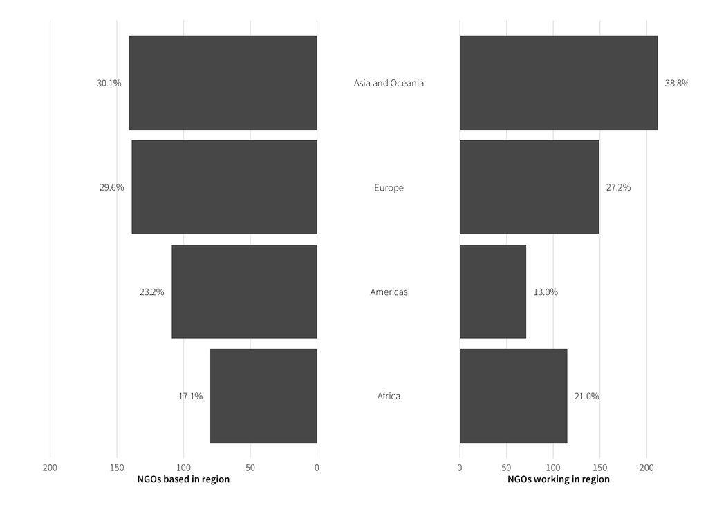

```r
plot.hq <- hq.regions %>%
  arrange(num) %>%
  mutate(region = factor(region, levels=region, ordered=TRUE),
         prop.nice = sprintf("%.1f%%", prop * 100))

plot.work <- work.regions %>%
  mutate(region = factor(region, levels=levels(plot.hq$region), ordered=TRUE),
         prop.nice = sprintf("%.1f%%", prop * 100))

fig.hq <- ggplot(plot.hq, aes(x=region, y=num)) +
  geom_bar(stat="identity") +
  geom_text(aes(label = prop.nice), size=2.5, hjust=1.3,
            family="Source Sans Pro Light") +
  labs(x=NULL, y="NGOs based in region") +
  scale_y_continuous(trans="reverse", expand = c(.1, .1)) +
  coord_flip(ylim=c(0, 200)) +
  theme_clean() +
  theme(axis.text.y = element_blank(),
        axis.line.y = element_blank(),
        plot.margin = unit(c(1,0.5,1,1), "lines"))

fig.work <- ggplot(plot.work, aes(x=region, y=num)) +
  geom_bar(stat="identity") +
  geom_text(aes(label = prop.nice), size=2.5, hjust=-0.3,
            family="Source Sans Pro Light") +
  labs(x=NULL, y="NGOs working in region") +
  scale_y_continuous(expand = c(.15, .15)) +
  coord_flip() +
  theme_clean() +
  theme(axis.text.y = element_text(hjust=0.5),
        axis.line.y = element_blank(),
        plot.margin = unit(c(1,1,1,0), "lines"))

fig.locations <- arrangeGrob(fig.hq, fig.work, nrow=1)
grid.draw(fig.locations)
```

```r
ggsave(fig.locations, filename=file.path(PROJHOME, "figures", "fig_locations.pdf"),
       width=5, height=1.5, units="in", device=cairo_pdf, scale=2.5)
ggsave(fig.locations, filename=file.path(PROJHOME, "figures", "fig_locations.png"),
       width=5, height=1.5, units="in", scale=2.5)
```

Where do different regional NGOs work?

```r
responses.full %>%
  mutate(home.region = countrycode(home.country, "country.name", "continent"),
         home.region = ifelse(home.country == "Kosovo", "Europe", home.region),
         home.region = ifelse(home.region == "Oceania", "Asia", home.region),
         home.region = ifelse(home.region == "Asia", "Asia and Oceania", home.region),
         work.region = countrycode(work.country, "country.name", "continent"),
         work.region = ifelse(work.country == "Kosovo", "Europe", work.region),
         work.region = ifelse(work.region == "Oceania", "Asia", work.region),
         work.region = ifelse(work.region == "Asia", "Asia and Oceania", work.region)) %>%
  filter(!is.na(work.region)) %>%
  group_by(home.region, work.region) %>%
  summarise(num = n()) %>%
  group_by(home.region) %>%
  mutate(prop.home.region = num / sum(num)) %>%
  print
```

```
## Source: local data frame [14 x 4]
## Groups: home.region [4]
##
##         home.region      work.region   num prop.home.region
##               (chr)            (chr) (int)            (dbl)
## 1            Africa           Africa    88       0.96703297
## 2            Africa Asia and Oceania     2       0.02197802
## 3            Africa           Europe     1       0.01098901
## 4          Americas           Africa    16       0.11594203
## 5          Americas         Americas    70       0.50724638
## 6          Americas Asia and Oceania    43       0.31159420
## 7          Americas           Europe     9       0.06521739
## 8  Asia and Oceania           Africa     2       0.01234568
## 9  Asia and Oceania Asia and Oceania   158       0.97530864
## 10 Asia and Oceania           Europe     2       0.01234568
## 11           Europe           Africa     9       0.05389222
## 12           Europe         Americas     2       0.01197605
## 13           Europe Asia and Oceania    17       0.10179641
## 14           Europe           Europe   139       0.83233533
```

## Government restrictions and oversight

Do members of the government or ruling party sit on the NGO’s board?

```r
responses.full %>%
  group_by(Q3.27) %>%
  summarise(num = n()) %>%
  filter(!is.na(Q3.27)) %>%
  mutate(prop = num / sum(num))
```

```
## Source: local data frame [3 x 3]
##
##        Q3.27   num       prop
##       (fctr) (int)      (dbl)
## 1         No   475 0.86837294
## 2        Yes    41 0.07495430
## 3 Don't know    31 0.05667276
```

For those that said yes, is the NGO required to have a government official sit on the board?

```r
responses.full %>%
  group_by(Q3.28) %>%
  summarise(num = n()) %>%
  filter(!is.na(Q3.28)) %>%
  mutate(prop = num / sum(num))
```

```
## Source: local data frame [3 x 3]
##
##        Q3.28   num  prop
##       (fctr) (int) (dbl)
## 1         No    25 0.625
## 2        Yes    13 0.325
## 3 Don't know     2 0.050
```

How restricted does the NGO feel by the host government?

```r
responses.full %>%
  group_by(Q3.29) %>%
  summarise(num = n()) %>%
  filter(!is.na(Q3.29)) %>%
  mutate(prop = num / sum(num)) %T>%
  {cat("Number of responses:", sum(.$num), "\n")}
```

```
## Number of responses: 547
```

```
## Source: local data frame [6 x 3]
##
##                    Q3.29   num       prop
##                   (fctr) (int)      (dbl)
## 1         Not restricted   201 0.36745887
## 2 Very little restricted   118 0.21572212
## 3    A little restricted    51 0.09323583
## 4    Somewhat restricted    93 0.17001828
## 5        Very restricted    41 0.07495430
## 6             Don't know    43 0.07861060
```

Which countries do NGOs say are restrictive?

```r
responses.full %>%
  filter(Q3.29 %in% c("Somewhat restricted", "Very restricted")) %>%
  group_by(work.country) %>%
  summarise(num = n()) %>%
  arrange(desc(num)) %T>%
  {cat("Number of countries:", nrow(.), "\n")}
```

```
## Number of countries: 66
```

```
## Source: local data frame [66 x 2]
##
##                             work.country   num
##                                    (chr) (int)
## 1                                  India    11
## 2                                Nigeria     7
## 3                                  Nepal     6
## 4                               Thailand     6
## 5                               Cambodia     5
## 6  Congo, the Democratic Republic of the     4
## 7                         United Kingdom     4
## 8                              Australia     3
## 9                                   Iraq     3
## 10                                 Italy     3
## ..                                   ...   ...
```

# NGO opinions of US activity

```r
# Select just the columns that have cowcodes embedded in them
active.embassies.raw <- responses.countries %>%
  select(contains("_c", ignore.case=FALSE)) %>%
  mutate_each(funs(as.numeric(levels(.))[.]))  # Convert values to numeric

# Select only the rows where they responded (i.e. not all columns are NA)
num.responses <- active.embassies.raw %>%
  rowwise() %>% do(all.missing = all(!is.na(.))) %>%
  ungroup() %>% mutate(all.missing = unlist(all.missing)) %>%
  summarise(total = sum(all.missing))

# Tidy cowcode columns and summarize most commonly mentioned countries
active.embassies <- active.embassies.raw %>%
  gather(country.raw, num) %>%
  group_by(country.raw) %>% summarise(num = sum(num, na.rm=TRUE)) %>%
  mutate(country.raw = str_replace(country.raw, "Q.*c", ""),
         country = countrycode(country.raw, "cown", "country.name"),
         country = ifelse(country.raw == "2070", "European Union", country)) %>%
  ungroup() %>% mutate(prop = num / num.responses$total,
                       prop.nice = sprintf("%.1f%%", prop * 100))
```

Which embassies or foreign governments NGOs were reported as active partners in the fight against human trafficking?

```r
active.embassies.top <- active.embassies %>%
  arrange(num) %>% select(-country.raw) %>%
  filter(num > 10) %>%
  mutate(country = factor(country, levels=country, ordered=TRUE)) %>%
  arrange(desc(num))

active.embassies %>% arrange(desc(num)) %>%
  select(-country.raw) %>% filter(num > 10)
```

```
## Source: local data frame [12 x 4]
##
##      num        country       prop prop.nice
##    (dbl)          (chr)      (dbl)     (chr)
## 1    260  United States 0.76923077     76.9%
## 2     43 United Kingdom 0.12721893     12.7%
## 3     35    Netherlands 0.10355030     10.4%
## 4     30         France 0.08875740      8.9%
## 5     26         Norway 0.07692308      7.7%
## 6     26 European Union 0.07692308      7.7%
## 7     24    Switzerland 0.07100592      7.1%
## 8     21         Sweden 0.06213018      6.2%
## 9     19      Australia 0.05621302      5.6%
## 10    17        Germany 0.05029586      5.0%
## 11    17          Italy 0.05029586      5.0%
## 12    12         Canada 0.03550296      3.6%
```

```r
nrow(active.embassies)  # Number of countries mentioned
```

```
## [1] 64
```

```r
num.responses$total  # Total responses
```

```
## [1] 338
```

```r
# Most active embassies
# Save Q3.7 to a CSV for hand coding
most.active <- responses.countries %>%
  select(Q3.7) %>%
  filter(!is.na(Q3.7))
write_csv(most.active, path=file.path(PROJHOME, "data",
                                      "most_active_WILL_BE_OVERWRITTEN.csv"))

# Read in hand-coded CSV
if (file.exists(file.path(PROJHOME, "data", "most_active.csv"))) {
  most.active <- read_csv(file.path(PROJHOME, "data", "most_active.csv"))
} else {
  stop("data/most_active.csv is missing")
}

# Split comma-separated countries, unnest them into multiple rows, and
# summarize most active countries
most.active.clean <- most.active %>%
  transform(clean = strsplit(clean, ",")) %>%
  unnest(clean) %>%
  mutate(clean = str_trim(clean)) %>%
  group_by(clean) %>%
  summarise(total = n()) %>%
  mutate(prop = total / nrow(most.active),
         prop.nice = sprintf("%.1f%%", prop * 100))
```

Which countries or embassies have been the *most* active?

```r
most.active.clean %>% arrange(desc(total))
```

```
## Source: local data frame [40 x 4]
##
##             clean total       prop prop.nice
##             (chr) (int)      (dbl)     (chr)
## 1   United States   188 0.70149254     70.1%
## 2            None    16 0.05970149      6.0%
## 3  European Union    14 0.05223881      5.2%
## 4             All    12 0.04477612      4.5%
## 5     Switzerland     8 0.02985075      3.0%
## 6       Australia     7 0.02611940      2.6%
## 7           Italy     7 0.02611940      2.6%
## 8  United Kingdom     7 0.02611940      2.6%
## 9     Netherlands     6 0.02238806      2.2%
## 10         Norway     6 0.02238806      2.2%
## ..            ...   ...        ...       ...
```

```r
nrow(most.active.clean) - 1  # Subtract one because of "None"s
```

```
## [1] 39
```

Over the last 10–15 years, has the United States or its embassy been active in the fight against human trafficking in X?

```r
responses.countries$Q3.8 %>% table %>% print %>% prop.table
```

```
## .
##         No        Yes Don't know
##         39        344        150
```

```
## .
##         No        Yes Don't know
## 0.07317073 0.64540338 0.28142589
```

Side-by-side graph of active countries + most active countries

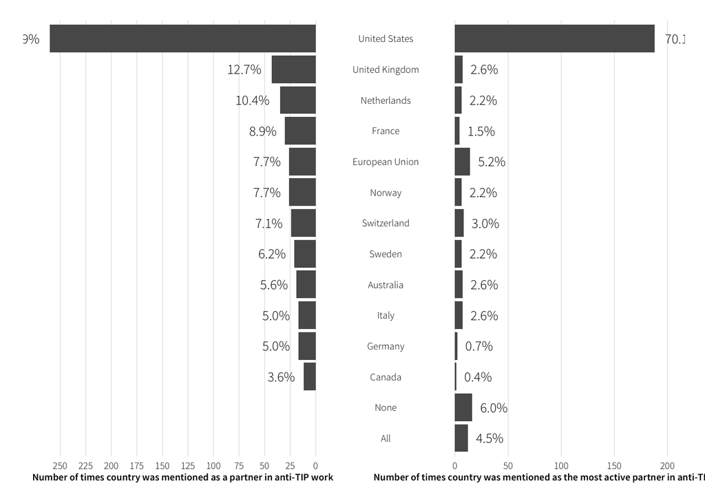

```r
plot.data <- active.embassies.top %>%
  bind_rows(data_frame(num=0, country=c("All", "None"),
                       prop=0, prop.nice="")) %>%
  arrange(num) %>%
  mutate(country = factor(country, levels=country, ordered=TRUE))

plot.data.active <- most.active.clean %>%
  filter(clean %in% plot.data$country) %>%
  mutate(country = factor(clean, levels=levels(plot.data$country), ordered=TRUE))

fig.active <- ggplot(plot.data, aes(x=country, y=num)) +
  geom_bar(stat="identity") +
  geom_text(aes(label = prop.nice), size=3.5, hjust=1.3,
            family="Source Sans Pro Light") +
  labs(x=NULL, y="Number of times country was mentioned as a partner in anti-TIP work") +
  scale_y_continuous(breaks=seq(0, max(active.embassies$num), by=25),
                     trans="reverse", expand = c(.1, .1)) +
  coord_flip() +
  theme_clean() +
  theme(axis.text.y = element_blank(),
        axis.line.y = element_blank(),
        plot.margin = unit(c(1,0.5,1,1), "lines"))

fig.most.active <- ggplot(plot.data.active, aes(x=country, y=total)) +
  geom_bar(stat="identity") +
  geom_text(aes(label = prop.nice), size=3.5, hjust=-0.3,
            family="Source Sans Pro Light") +
  labs(x=NULL, y="Number of times country was mentioned as the most active partner in anti-TIP work") +
  scale_y_continuous(expand = c(.15, .15)) +
  coord_flip() +
  theme_clean() +
  theme(axis.text.y = element_text(hjust=0.5),
        axis.line.y = element_blank(),
        plot.margin = unit(c(1,1,1,0), "lines"))

fig.embassies <- arrangeGrob(fig.active, fig.most.active, nrow=1)
grid.draw(fig.embassies)
```

```r
ggsave(fig.embassies, filename=file.path(PROJHOME, "figures", "fig_embassies.pdf"),
       width=5, height=2, units="in", device=cairo_pdf, scale=2.5)
ggsave(fig.embassies, filename=file.path(PROJHOME, "figures", "fig_embassies.png"),
       width=5, height=2, units="in", scale=2.5)

saveRDS(active.embassies, file.path(PROJHOME, "data", "active_embassies.rds"))
saveRDS(most.active.clean, file.path(PROJHOME, "data", "most_active_embassies.rds"))
```

Actual US activities

```r
cols <- c("Q3.9_1", "Q3.9_2", "Q3.9_3", "Q3.9_4", "Q3.9_5",
          "Q3.9_6", "Q3.9_7", "Q3.9_8", "Q3.9_9", "Q3.9_10")
labels <- c("Asking for legislation", "Convening conferences or workshops",
            "Raising awareness", "Providing resources or funding",
            "Increasing government attention", "Training government officials",
            "Contributing to a government action plan", "Other", "Don't know",
            "The US has not been involved in trafficking issues")

activities <- separate.answers.summary(responses.countries, cols, labels)
activities$denominator  # Number of responses
```

```
## [1] 532
```

```r
activities$df
```

```
## Source: local data frame [10 x 4]
##
##                                                Answer Responses     %   plot.pct
##                                                (fctr)     (int) (dbl)      (dbl)
## 1                              Asking for legislation       165 31.02 0.31015038
## 2                  Convening conferences or workshops       208 39.10 0.39097744
## 3                                   Raising awareness       214 40.23 0.40225564
## 4                      Providing resources or funding       212 39.85 0.39849624
## 5                     Increasing government attention       217 40.79 0.40789474
## 6                       Training government officials       146 27.44 0.27443609
## 7            Contributing to a government action plan       114 21.43 0.21428571
## 8                                               Other        43  8.08 0.08082707
## 9                                          Don't know        26  4.89 0.04887218
## 10 The US has not been involved in trafficking issues       166 31.20 0.31203008
```

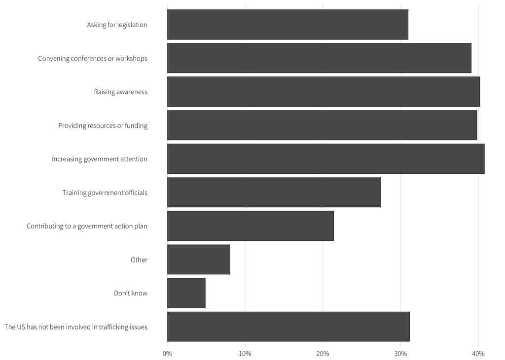

```r
plot.data <- activities$df %>%
  mutate(Answer=factor(Answer, levels=rev(labels), ordered=TRUE))

fig.activities <- ggplot(plot.data, aes(x=Answer, y=Responses)) +
  geom_bar(aes(y=plot.pct), stat="identity") +
  labs(x=NULL, y=NULL) +
  scale_y_continuous(labels = percent,
                     breaks = seq(0, max(round(plot.data$plot.pct, 1)), by=0.1)) +
  coord_flip() + theme_clean()
fig.activities
```

```r
ggsave(fig.activities, filename=file.path(PROJHOME, "figures", "fig_activities.pdf"),
       width=6.5, height=5, units="in", device=cairo_pdf)
ggsave(fig.activities, filename=file.path(PROJHOME, "figures", "fig_activities.png"),
       width=6.5, height=5, units="in")
```

# NGO opinions of US importance

## General importance

```r
plot.data <- responses.full %>%
  group_by(Q3.19) %>%
  summarize(num = n()) %>%
  na.omit() %>%
  mutate(prop = num / sum(num),
         prop.nice = sprintf("%.1f%%", prop * 100),
         Q3.19 = factor(Q3.19, levels=rev(levels(Q3.19)), ordered=TRUE))
plot.data
```

```
## Source: local data frame [4 x 4]
##
##                      Q3.19   num      prop prop.nice
##                     (fctr) (int)     (dbl)     (chr)
## 1     Most important actor   139 0.2662835     26.6%
## 2 Somewhat important actor   182 0.3486590     34.9%
## 3   Not an important actor    68 0.1302682     13.0%
## 4               Don't know   133 0.2547893     25.5%
```

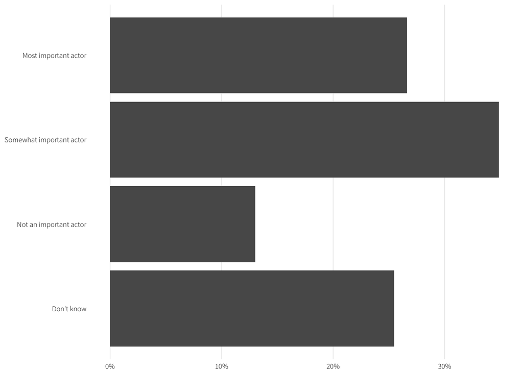

```r
fig.us_importance <- ggplot(plot.data, aes(x=Q3.19, y=prop)) +
  geom_bar(stat="identity") +
  labs(x=NULL, y=NULL) +
  scale_y_continuous(labels = percent,
                     breaks = seq(0, max(round(plot.data$num, 1)), by=0.1)) +
  coord_flip() + theme_clean()
fig.us_importance
```

```r
ggsave(fig.us_importance, filename=file.path(PROJHOME, "figures", "fig_us_importance.pdf"),
       width=6.5, height=5, units="in", device=cairo_pdf)
ggsave(fig.us_importance, filename=file.path(PROJHOME, "figures", "fig_us_importance.png"),
       width=6.5, height=5, units="in")
```

Average importance by country

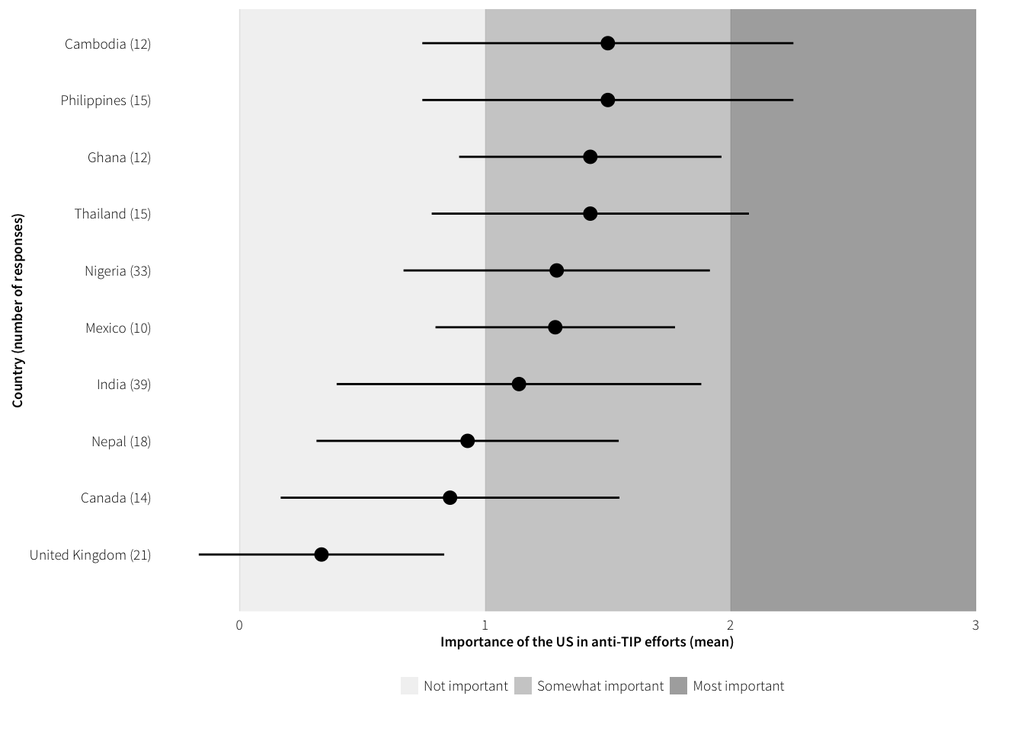

```r
importance.plot <- country.indexes %>%
  filter(num.responses >= 10) %>%
  arrange(importance_score) %>%
  mutate(country_label = factor(work.country, levels=unique(work.country),
                                labels=paste0(work.country, " (", num.responses, ")"),
                                ordered=TRUE))

fig.avg_importance <- ggplot(importance.plot, aes(x=country_label, y=importance_score)) +
  geom_rect(data=importance.levels, aes(x=NULL, y=NULL, ymin=start, ymax=end,
                                        xmin=0, xmax=Inf, fill=level.ordered), alpha=0.5) +
  geom_pointrange(aes(ymax=importance_score + importance_stdev,
                      ymin=importance_score - importance_stdev)) +
  labs(x="Country (number of responses)",
       y="Importance of the US in anti-TIP efforts (mean)") +
  scale_fill_manual(values=c("grey90", "grey60", "grey30"), name=NULL) +
  coord_flip() +
  theme_clean() + theme(legend.position="bottom")
fig.avg_importance
```

```r
ggsave(fig.avg_importance, filename=file.path(PROJHOME, "figures", "fig_avg_importance.pdf"),
       width=6.5, height=5, units="in", device=cairo_pdf)
ggsave(fig.avg_importance, filename=file.path(PROJHOME, "figures", "fig_avg_importance.png"),
       width=6.5, height=5, units="in")
```

## Are opinions of the US’s importance associated with…?

```r
df.importance <- responses.full %>%
  select(Q3.19, work.country, change_policy, avg_tier, improve_tip, change_policy,
         importance, received.funding, us.involvement, total.funding,
         total.freedom, us.hq, time.spent=Q2.1) %>%
  filter(!is.na(Q3.19)) %>%
  mutate(importance_factor = factor(Q3.19, ordered=FALSE),
         log.total.funding = log1p(total.funding),
         time.spent = as.numeric(time.spent))
```

### Average tier rating

Average tier doesn’t show much because it doesn’t show any changes in time—just how bad the country is in general?

```r
importance.means <- df.importance %>%
  group_by(Q3.19) %>%
  summarize(avg_points = mean(avg_tier, na.rm=TRUE),
            var_points = var(avg_tier, na.rm=TRUE)) %>%
  print
```

```
## Source: local data frame [4 x 3]
##
##                      Q3.19 avg_points var_points
##                     (fctr)      (dbl)      (dbl)
## 1     Most important actor   2.053344  0.1171988
## 2 Somewhat important actor   1.920723  0.2256463
## 3   Not an important actor   1.763046  0.3492590
## 4               Don't know   1.744558  0.2864291
```

Plot group means and distributions

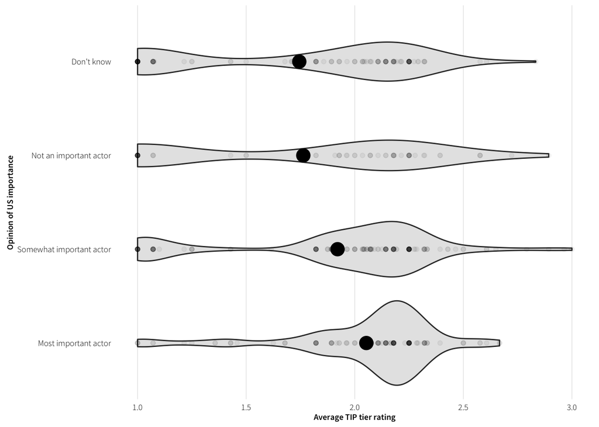

```r
fig.importance <- ggplot(df.importance, aes(x=Q3.19, y=avg_tier)) +
  geom_violin(fill="grey90") +
  geom_point(alpha=0.05, show.legend=FALSE) +
  geom_point(data=importance.means, aes(x=Q3.19, y=avg_points), size=5, show.legend=FALSE) +
  labs(x="Opinion of US importance", y="Average TIP tier rating") +
  coord_flip() + theme_clean()
fig.importance
```

Those means appear slightly different from each other. Is that really the case? Check with ANOVA, which assumes homogenous variance across groups. Throw every possible test at it—if null is rejected (p < 0.05 or whatever) then variance is likely heterogenous: ([helpful reference](http://www.r-bloggers.com/analysis-of-variance-anova-for-multiple-comparisons/))

```r
bartlett.test(avg_tier ~ importance_factor, data=df.importance)
```

```
##
##  Bartlett test of homogeneity of variances
##
## data:  avg_tier by importance_factor
## Bartlett's K-squared = 35.422, df = 3, p-value = 9.923e-08
```

```r
car::leveneTest(avg_tier ~ importance_factor, data=df.importance)
```

```
## Levene's Test for Homogeneity of Variance (center = median)
##        Df F value    Pr(>F)
## group   3  14.266 6.052e-09 ***
##       517
## ---
## Signif. codes:  0 '***' 0.001 '**' 0.01 '*' 0.05 '.' 0.1 ' ' 1
```

```r
fligner.test(avg_tier ~ importance_factor, data=df.importance)  # Uses median
```

```
##
##  Fligner-Killeen test of homogeneity of variances
##
## data:  avg_tier by importance_factor
## Fligner-Killeen:med chi-squared = 28.052, df = 3, p-value = 3.542e-06
```

```r
kruskal.test(avg_tier ~ importance_factor, data=df.importance)  # Nonparametric
```

```
##
##  Kruskal-Wallis rank sum test
##
## data:  avg_tier by importance_factor
## Kruskal-Wallis chi-squared = 23.591, df = 3, p-value = 3.041e-05
```

All of those p-values are tiny, so it’s clear that variance is not the same across groups. However, there’s a [rule of thumb](http://stats.stackexchange.com/q/56971/3025) ([super detailed example](http://stats.stackexchange.com/a/91881/3025)) that ANOVA is robust to heterogeneity of variance as long as the largest variance is less than four times the smallest variance.

Given that rule of thumb, the variance here isn’t that much of an issue

```r
df.importance %>% group_by(importance_factor) %>%
  summarise(variance = var(avg_tier, na.rm=TRUE)) %>%
  do(data_frame(ratio = max(.$variance) / min(.$variance)))
```

```
## Source: local data frame [1 x 1]
##
##      ratio
##      (dbl)
## 1 2.980057
```

It would be cool to use Bayesian ANOVA to account for non-homogenous variances (see [John Kruschke’s evangelizing](http://doingbayesiandataanalysis.blogspot.mx/2011/04/anova-with-non-homogeneous-variances.html)), since it handles violations of ANOVA assumptions nicely. However, in his example, the ratio of min/max variance is huge, so it *does* lead to big differences in results:

```r
#
# read_csv("http://www.indiana.edu/~kruschke/DoingBayesianDataAnalysis/Programs/NonhomogVarData.csv") %>%
#   group_by(Group) %>%
#   summarise(variance = var(Y)) %>%
#   do(data_frame(ratio = max(.$variance) / min(.$variance)))
#   # ratio = 64
#
```

With the variance issue handled, run the ANOVA:

```r
importance.aov <- aov(avg_tier ~ importance_factor, data=df.importance)
summary(importance.aov)
```

```
##                    Df Sum Sq Mean Sq F value  Pr(>F)
## importance_factor   3   7.79  2.5963   11.38 3.1e-07 ***
## Residuals         517 118.00  0.2282
## ---
## Signif. codes:  0 '***' 0.001 '**' 0.01 '*' 0.05 '.' 0.1 ' ' 1
## 1 observation deleted due to missingness
```

There is some significant difference between groups. Look at pairwise comparisons between all the groups to (kind of) decompose that finding:

```r
(importance.pairs <- TukeyHSD(importance.aov, "importance_factor"))
```

```
##   Tukey multiple comparisons of means
##     95% family-wise confidence level
##
## Fit: aov(formula = avg_tier ~ importance_factor, data = df.importance)
##
## $importance_factor
##                                                       diff        lwr          upr     p adj
## Somewhat important actor-Most important actor   -0.1326211 -0.2714899  0.006247627 0.0673115
## Not an important actor-Most important actor     -0.2902984 -0.4725198 -0.108076873 0.0002725
## Don't know-Most important actor                 -0.3087859 -0.4581435 -0.159428195 0.0000009
## Not an important actor-Somewhat important actor -0.1576772 -0.3328160  0.017461509 0.0947138
## Don't know-Somewhat important actor             -0.1761647 -0.3167941 -0.035535362 0.0072161
## Don't know-Not an important actor               -0.0184875 -0.2020542  0.165079256 0.9938662
```

Plot the differences:

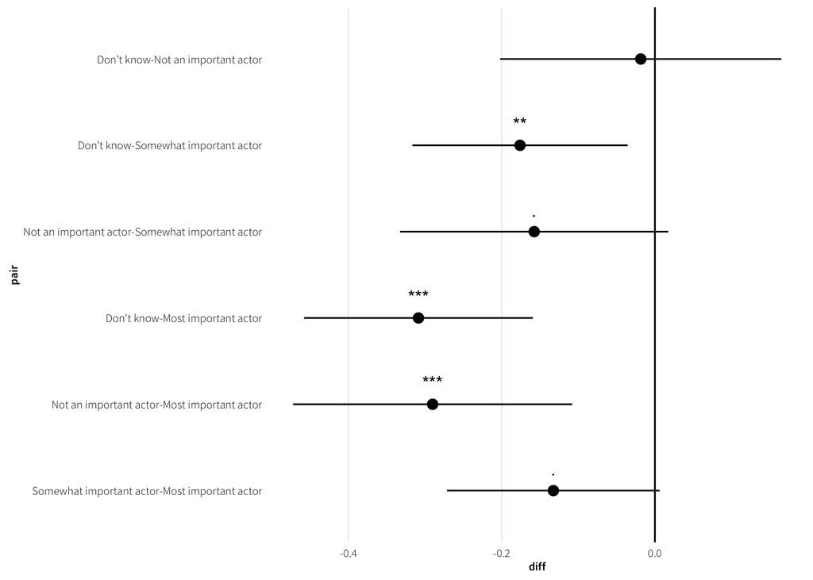

```r
importance.pairs.plot <- data.frame(importance.pairs$importance_factor) %>%
  mutate(pair = row.names(.),
         pair = factor(pair, levels=pair, ordered=TRUE),
         stars = add.stars(p.adj))

fig.importance.pairs <- ggplot(importance.pairs.plot,
                               aes(x=pair, y=diff, ymax=upr, ymin=lwr)) +
  geom_hline(yintercept=0) +
  geom_text(aes(label=stars), nudge_x=0.25) +
  geom_pointrange() +
  theme_clean() + coord_flip()
fig.importance.pairs
```

Another way of checking group means in non-homogenous data is to use ordinal logistic regression. Here’s an ordered logit and corresponding predicted probabilities:

```r
model.importance <- ordinal::clm(Q3.19 ~ avg_tier, data=df.importance,
                                 link="logit", Hess=TRUE)
summary(model.importance)
```

```
## formula: Q3.19 ~ avg_tier
## data:    df.importance
##
##  link  threshold nobs logLik  AIC     niter max.grad cond.H
##  logit flexible  521  -679.73 1367.46 6(0)  1.69e-12 2.1e+02
##
## Coefficients:
##          Estimate Std. Error z value Pr(>|z|)
## avg_tier  -0.8863     0.1618  -5.479 4.27e-08 ***
## ---
## Signif. codes:  0 '***' 0.001 '**' 0.01 '*' 0.05 '.' 0.1 ' ' 1
##
## Threshold coefficients:
##                                                 Estimate Std. Error z value
## Most important actor|Somewhat important actor    -2.7248     0.3305  -8.244
## Somewhat important actor|Not an important actor  -1.1795     0.3119  -3.782
## Not an important actor|Don't know                -0.5470     0.3092  -1.769
## (1 observation deleted due to missingness)
```

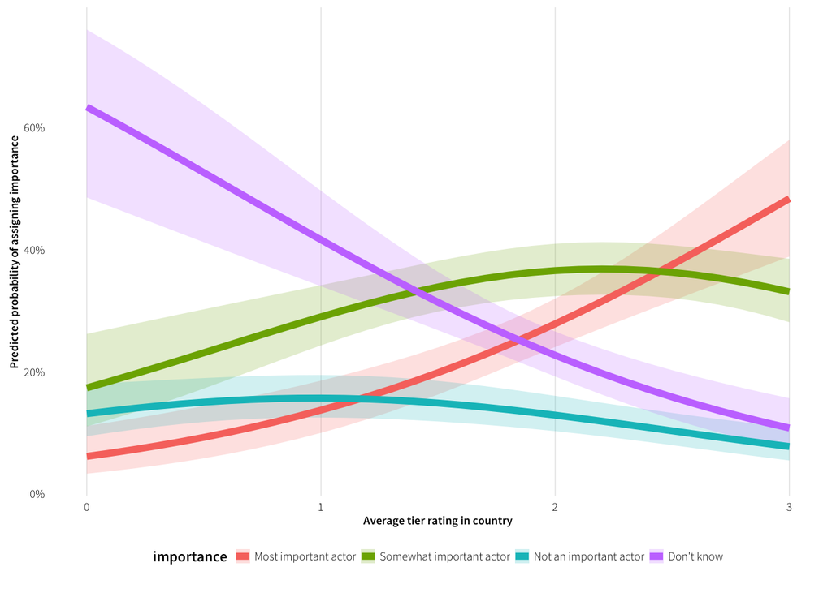

```r
# Predicted probabilities
newdata <- data_frame(avg_tier = seq(0, 3, 0.1))
pred.importance <- predict(model.importance, newdata, interval=TRUE)

# Create plot data
pred.plot.lower <- cbind(newdata, pred.importance$lwr) %>%
  gather(importance, lwr, -c(1:ncol(newdata)))
pred.plot.upper <- cbind(newdata, pred.importance$upr) %>%
  gather(importance, upr, -c(1:ncol(newdata)))

pred.plot.data <- cbind(newdata, pred.importance$fit) %>%
  gather(importance, importance_prob, -c(1:ncol(newdata))) %>%
  left_join(pred.plot.lower, by=c("avg_tier", "importance")) %>%
  left_join(pred.plot.upper, by=c("avg_tier", "importance"))

importance.colors <- c("grey20", "grey40", "grey60", "grey80")
ggplot(pred.plot.data, aes(x=avg_tier, y=importance_prob)) +
  geom_ribbon(aes(ymax=upr, ymin=lwr, fill=importance),
              alpha=0.2) +
  geom_line(aes(colour=importance), size=2) +
  scale_y_continuous(labels=percent) +
  labs(x="Average tier rating in country",
       y="Predicted probability of assigning importance") +
  # scale_fill_manual(values=importance.colors, name=NULL) +
  # scale_colour_manual(values=importance.colors, name=NULL) +
  theme_clean()
```

### Improvement in TIP scores

Opinions of importance are not related to changes in TIP score. The average Improvement in TIP rating is the same for each possible answer of importance.

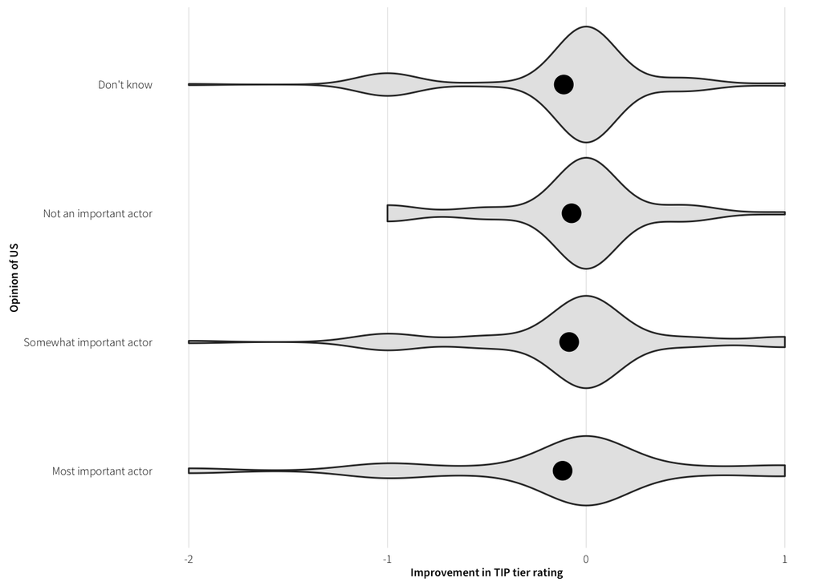

```r
ggplot(df.importance, aes(x=Q3.19, y=improve_tip)) +
  geom_violin(fill="grey90") +
  geom_point(stat="summary", fun.y="mean", size=5) +
  labs(x="Opinion of US", y="Improvement in TIP tier rating") +
  coord_flip() + theme_clean()
```

Variance is equal in all groups:

```r
kruskal.test(improve_tip ~ importance_factor, data=df.importance)
```

```
##
##  Kruskal-Wallis rank sum test
##
## data:  improve_tip by importance_factor
## Kruskal-Wallis chi-squared = 0.098657, df = 3, p-value = 0.992
```

ANOVA shows no differences:

```r
change.anova <- aov(improve_tip ~ importance_factor, data=df.importance)
summary(change.anova)
```

```
##                    Df Sum Sq Mean Sq F value Pr(>F)
## importance_factor   3   0.16 0.05178   0.183  0.908
## Residuals         517 146.15 0.28270
## 1 observation deleted due to missingness
```

```r
TukeyHSD(change.anova)
```

```
##   Tukey multiple comparisons of means
##     95% family-wise confidence level
##
## Fit: aov(formula = improve_tip ~ importance_factor, data = df.importance)
##
## $importance_factor
##                                                         diff        lwr       upr     p adj
## Somewhat important actor-Most important actor    0.033069677 -0.1214814 0.1876208 0.9461281
## Not an important actor-Most important actor      0.045175624 -0.1576240 0.2479753 0.9397810
## Don't know-Most important actor                  0.005923081 -0.1603014 0.1721476 0.9997222
## Not an important actor-Somewhat important actor  0.012105947 -0.1828111 0.2070230 0.9985387
## Don't know-Somewhat important actor             -0.027146596 -0.1836571 0.1293639 0.9701783
## Don't know-Not an important actor               -0.039252543 -0.2435494 0.1650443 0.9601399
```

### Change in Cho scores

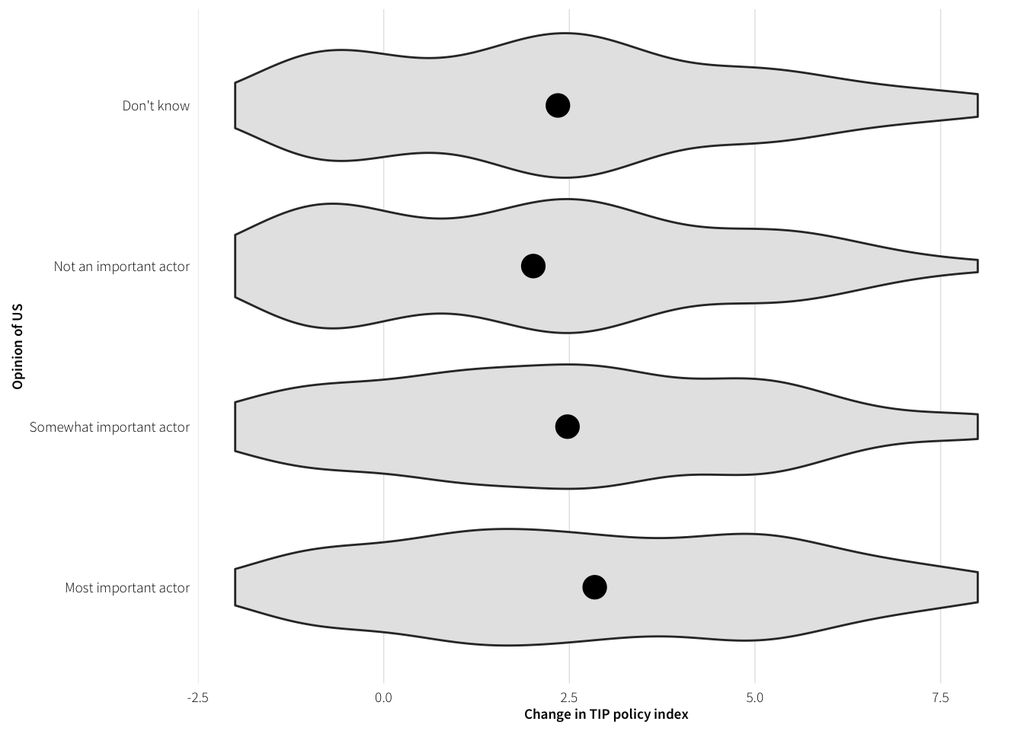

```r
ggplot(df.importance, aes(x=Q3.19, y=change_policy)) +
  geom_violin(fill="grey90") +
  geom_point(stat="summary", fun.y="mean", size=5) +
  labs(x="Opinion of US", y="Change in TIP policy index") +
  coord_flip() + theme_clean()
```

Variance is equal in all groups:

```r
kruskal.test(change_policy ~ importance_factor, data=df.importance)
```

```
##
##  Kruskal-Wallis rank sum test
##
## data:  change_policy by importance_factor
## Kruskal-Wallis chi-squared = 4.7541, df = 3, p-value = 0.1907
```

ANOVA shows no differences

```r
cho.change.anova <- aov(change_policy ~ importance_factor, data=df.importance)
summary(cho.change.anova)  # (⌐○Ϟ○)  ♥  \(•◡•)/
```

```
##                    Df Sum Sq Mean Sq F value Pr(>F)
## importance_factor   3     35  11.769   1.766  0.153
## Residuals         517   3445   6.663
## 1 observation deleted due to missingness
```

```r
TukeyHSD(cho.change.anova)
```

```
##   Tukey multiple comparisons of means
##     95% family-wise confidence level
##
## Fit: aov(formula = change_policy ~ importance_factor, data = df.importance)
##
## $importance_factor
##                                                       diff        lwr       upr     p adj
## Somewhat important actor-Most important actor   -0.3665885 -1.1169034 0.3837264 0.5893507
## Not an important actor-Most important actor     -0.8270207 -1.8115725 0.1575310 0.1344747
## Don't know-Most important actor                 -0.4958620 -1.3028488 0.3111249 0.3888147
## Not an important actor-Somewhat important actor -0.4604322 -1.4067155 0.4858511 0.5926605
## Don't know-Somewhat important actor             -0.1292735 -0.8891009 0.6305540 0.9717760
## Don't know-Not an important actor                0.3311588 -0.6606615 1.3229791 0.8251392
```

### US funding received by the responding organization

Organizations that have been received funding from the US are more likely to consider the US to play an important role in the countries they work in.

```r
funding.table <- df.importance %>%
  xtabs(~ Q3.19 + received.funding, .) %>% print
```

```
##                           received.funding
## Q3.19                      FALSE TRUE
##   Most important actor        81   58
##   Somewhat important actor   149   33
##   Not an important actor      65    3
##   Don't know                 131    2
```

There’s an overall significant difference (though two of the cells are really small here)

```r
(funding.chi <- chisq.test(funding.table))
```

```
##
##  Pearson's Chi-squared test
##
## data:  funding.table
## X-squared = 84.566, df = 3, p-value < 2.2e-16
```

```r
# Cramer's V for standardized measure of association
assocstats(funding.table)
```

```
##                     X^2 df P(> X^2)
## Likelihood Ratio 91.734  3        0
## Pearson          84.566  3        0
##
## Phi-Coefficient   : NA
## Contingency Coeff.: 0.373
## Cramer's V        : 0.402
```

```r
# Components of chi-squared
(components <- funding.chi$residuals^2)
```

```
##                           received.funding
## Q3.19                             FALSE         TRUE
##   Most important actor      9.275164424 41.158542132
##   Somewhat important actor  0.001495267  0.006635247
##   Not an important actor    1.628262816  7.225416244
##   Don't know                4.647505115 20.623303950
```

```r
round(1-pchisq(components, funding.chi$parameter), 3)
```

```
##                           received.funding
## Q3.19                      FALSE  TRUE
##   Most important actor     0.026 0.000
##   Somewhat important actor 1.000 1.000
##   Not an important actor   0.653 0.065
##   Don't know               0.200 0.000
```

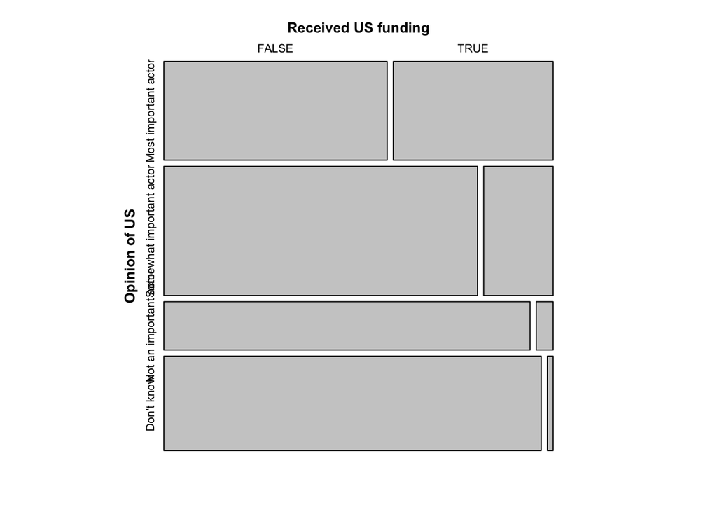

```r
# Visualize differences
mosaic(funding.table,
       labeling_args=list(set_varnames=c(received.funding="Received US funding",
                                         Q3.19="Opinion of US"),
                          gp_labels=(gpar(fontsize=8))),
       gp_varnames=gpar(fontsize=10, fontface=2))
```

### US funding received by the country the organization works in

Opinions of importance are strongly associated with US TIP funding given to a country. Organizations are more likely to think the US is an important actor if they work in countries receiving more anti-TIP funding.

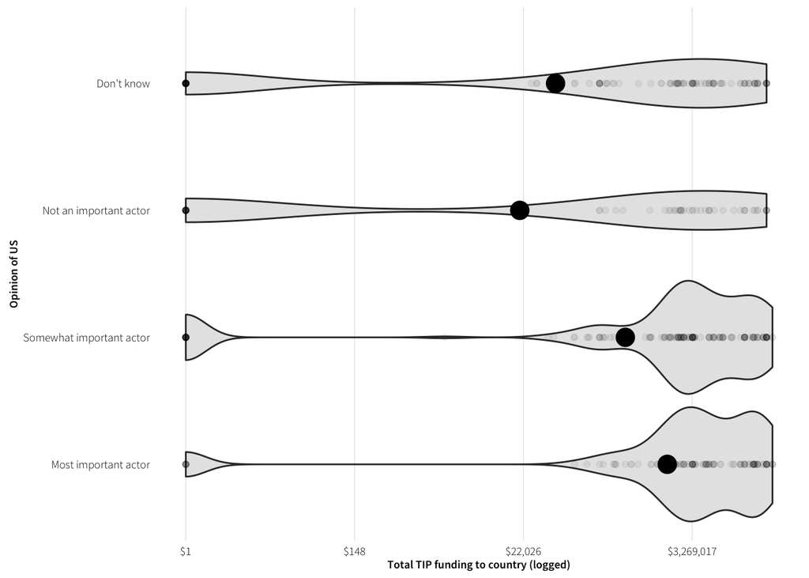

```r
ggplot(df.importance, aes(x=Q3.19, y=log.total.funding)) +
  geom_violin(fill="grey90") +
  geom_point(alpha=0.05) +
  geom_point(stat="summary", fun.y="mean", size=5) +
  labs(x="Opinion of US", y="Total TIP funding to country (logged)") +
  scale_y_continuous(labels=trans_format("exp", dollar_format())) +
  coord_flip() + theme_clean()
```

Variance is not equal in all groups:

```r
kruskal.test(log.total.funding ~ importance_factor, data=df.importance)
```

```
##
##  Kruskal-Wallis rank sum test
##
## data:  log.total.funding by importance_factor
## Kruskal-Wallis chi-squared = 21.659, df = 3, p-value = 7.68e-05
```

Ratio is 3ish, which is below 4, so heterogenous variance is okayish:

```r
df.importance %>% group_by(importance_factor) %>%
  summarise(variance = var(log.total.funding, na.rm=TRUE)) %>%
  do(data_frame(ratio = max(.$variance) / min(.$variance)))
```

```
## Source: local data frame [1 x 1]
##
##      ratio
##      (dbl)
## 1 3.006739
```

ANOVA shows significant differences:

```r
funding.anova <- aov(log.total.funding ~ importance_factor, data=df.importance)
summary(funding.anova)
```

```
##                    Df Sum Sq Mean Sq F value   Pr(>F)
## importance_factor   3   1234   411.2   11.92 1.48e-07 ***
## Residuals         508  17524    34.5
## ---
## Signif. codes:  0 '***' 0.001 '**' 0.01 '*' 0.05 '.' 0.1 ' ' 1
## 10 observations deleted due to missingness
```

```r
(funding.pairs <- TukeyHSD(funding.anova))
```

```
##   Tukey multiple comparisons of means
##     95% family-wise confidence level
##
## Fit: aov(formula = log.total.funding ~ importance_factor, data = df.importance)
##
## $importance_factor
##                                                      diff       lwr        upr     p adj
## Somewhat important actor-Most important actor   -1.241784 -2.974848  0.4912799 0.2526710
## Not an important actor-Most important actor     -4.368679 -6.625553 -2.1118050 0.0000050
## Don't know-Most important actor                 -3.309266 -5.169210 -1.4493229 0.0000337
## Not an important actor-Somewhat important actor -3.126895 -5.283433 -0.9703573 0.0011831
## Don't know-Somewhat important actor             -2.067482 -3.804308 -0.3306565 0.0121187
## Don't know-Not an important actor                1.059413 -1.200352  3.3191771 0.6217846
```

See those differences

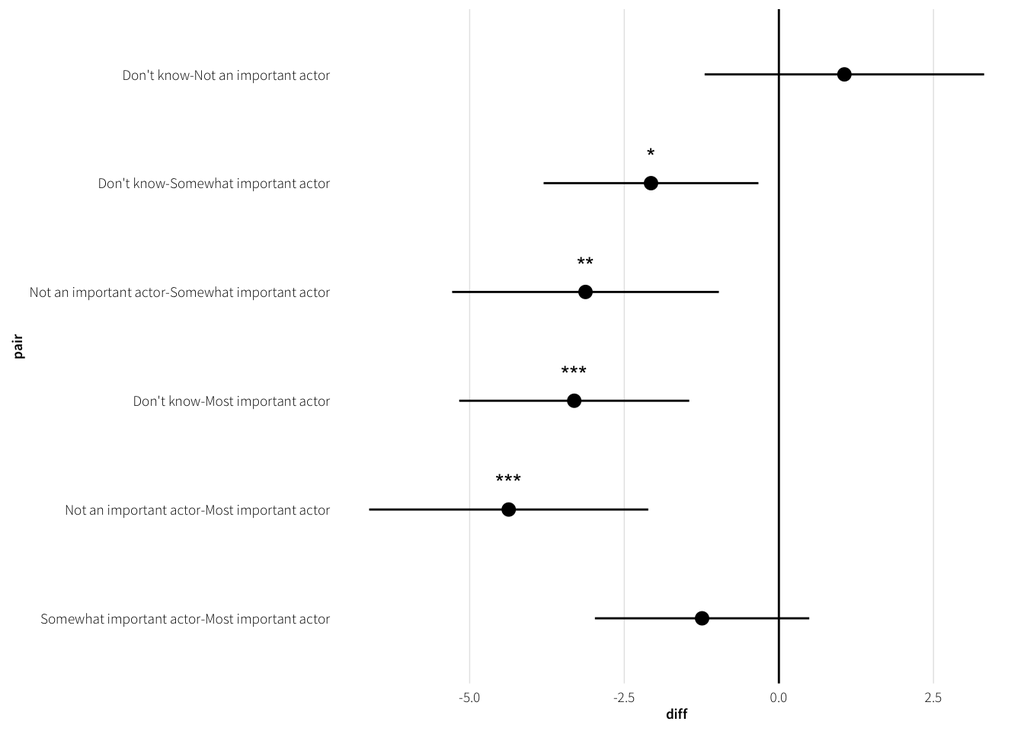

```r
funding.pairs.plot <- data.frame(funding.pairs$importance_factor) %>%
  mutate(pair = row.names(.),
         pair = factor(pair, levels=pair, ordered=TRUE),
         stars = add.stars(p.adj))

fig.funding.pairs <- ggplot(funding.pairs.plot,
                            aes(x=pair, y=diff, ymax=upr, ymin=lwr)) +
  geom_hline(yintercept=0) +
  geom_text(aes(label=stars), nudge_x=0.25) +
  geom_pointrange() +
  theme_clean() + coord_flip()
fig.funding.pairs
```

### Democracy (Freedom House political rights + civil liberties)

US importance appears to be associated with the level of democracy in a country. NGOs working in countries with worse democracy (higher numbers of the total freedom scale) are more likely to see the US as the most important anti-TIP actor in that country. Or, rather, on average total freedom is worse in countries where NGOs indicate the US as the most important actor.

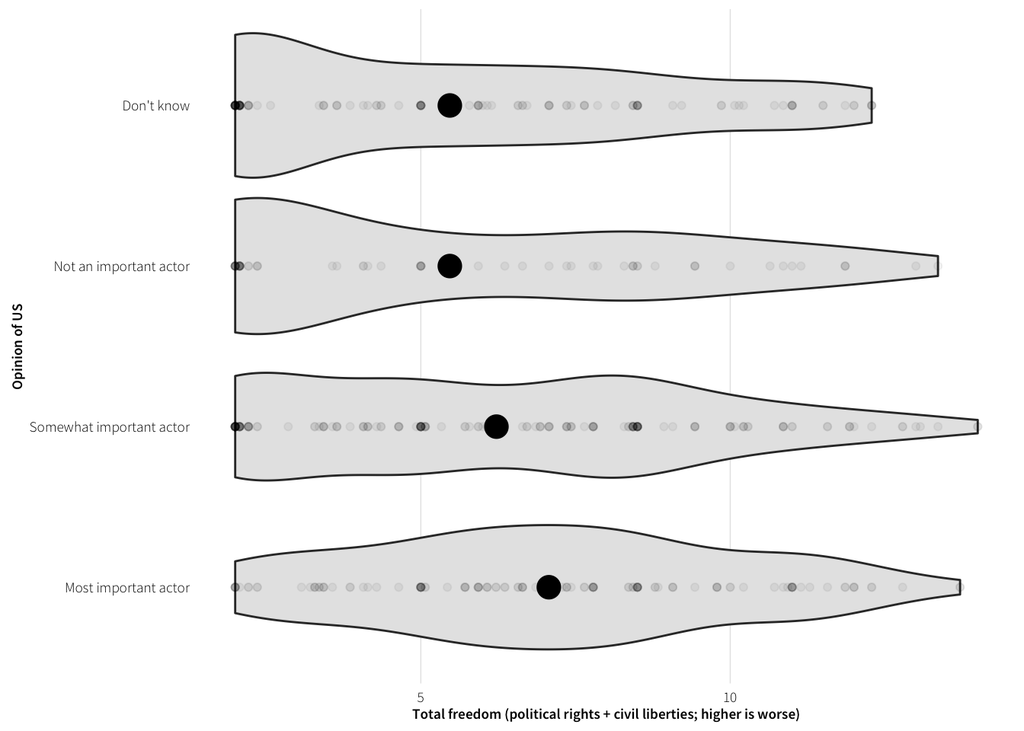

```r
ggplot(df.importance, aes(x=Q3.19, y=total.freedom)) +
  geom_violin(fill="grey90") +
  geom_point(alpha=0.05) +
  geom_point(stat="summary", fun.y="mean", size=5) +
  labs(x="Opinion of US",
       y="Total freedom (political rights + civil liberties; higher is worse)") +
  coord_flip() + theme_clean()
```

Variance is not equal in all groups:

```r
kruskal.test(total.freedom ~ importance_factor, data=df.importance)
```

```
##
##  Kruskal-Wallis rank sum test
##
## data:  total.freedom by importance_factor
## Kruskal-Wallis chi-squared = 21.262, df = 3, p-value = 9.288e-05
```

Ratio between min and max variance is low, so we’re okay:

```r
df.importance %>% group_by(importance_factor) %>%
  summarise(variance = var(total.freedom, na.rm=TRUE)) %>%
  do(data_frame(ratio = max(.$variance) / min(.$variance)))
```

```
## Source: local data frame [1 x 1]
##
##      ratio
##      (dbl)
## 1 1.431773
```

ANOVA shows significant differences:

```r
democracy.anova <- aov(total.freedom ~ importance_factor, data=df.importance)
summary(democracy.anova)
```

```
##                    Df Sum Sq Mean Sq F value   Pr(>F)
## importance_factor   3    208   69.24   6.486 0.000259 ***
## Residuals         512   5465   10.67
## ---
## Signif. codes:  0 '***' 0.001 '**' 0.01 '*' 0.05 '.' 0.1 ' ' 1
## 6 observations deleted due to missingness
```

```r
(democracy.pairs <- TukeyHSD(democracy.anova))
```

```
##   Tukey multiple comparisons of means
##     95% family-wise confidence level
##
## Fit: aov(formula = total.freedom ~ importance_factor, data = df.importance)
##
## $importance_factor
##                                                          diff       lwr        upr     p adj
## Somewhat important actor-Most important actor   -0.8469545051 -1.804602  0.1106928 0.1041491
## Not an important actor-Most important actor     -1.6001193070 -2.852380 -0.3478582 0.0058153
## Don't know-Most important actor                 -1.5999919833 -2.630782 -0.5692024 0.0004202
## Not an important actor-Somewhat important actor -0.7531648018 -1.950937  0.4446072 0.3677940
## Don't know-Somewhat important actor             -0.7530374782 -1.716898  0.2108229 0.1842105
## Don't know-Not an important actor                0.0001273237 -1.256892  1.2571462 1.0000000
```

View the differences:

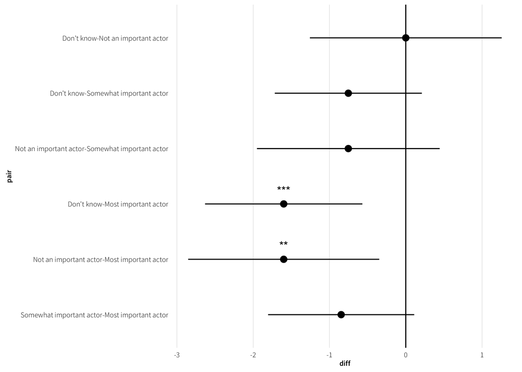

```r
democracy.pairs.plot <- data.frame(democracy.pairs$importance_factor) %>%
  mutate(pair = row.names(.),
         pair = factor(pair, levels=pair, ordered=TRUE),
         stars = add.stars(p.adj))

fig.democracy.pairs <- ggplot(democracy.pairs.plot,
                            aes(x=pair, y=diff, ymax=upr, ymin=lwr)) +
  geom_hline(yintercept=0) +
  geom_text(aes(label=stars), nudge_x=0.25) +
  geom_pointrange() +
  theme_clean() + coord_flip()
fig.democracy.pairs
```

### TODO: Type of TIP work

### Time spent on trafficking

The time NGOs spend on trafficking issues does not appear to be associated with their opinion of US importance.

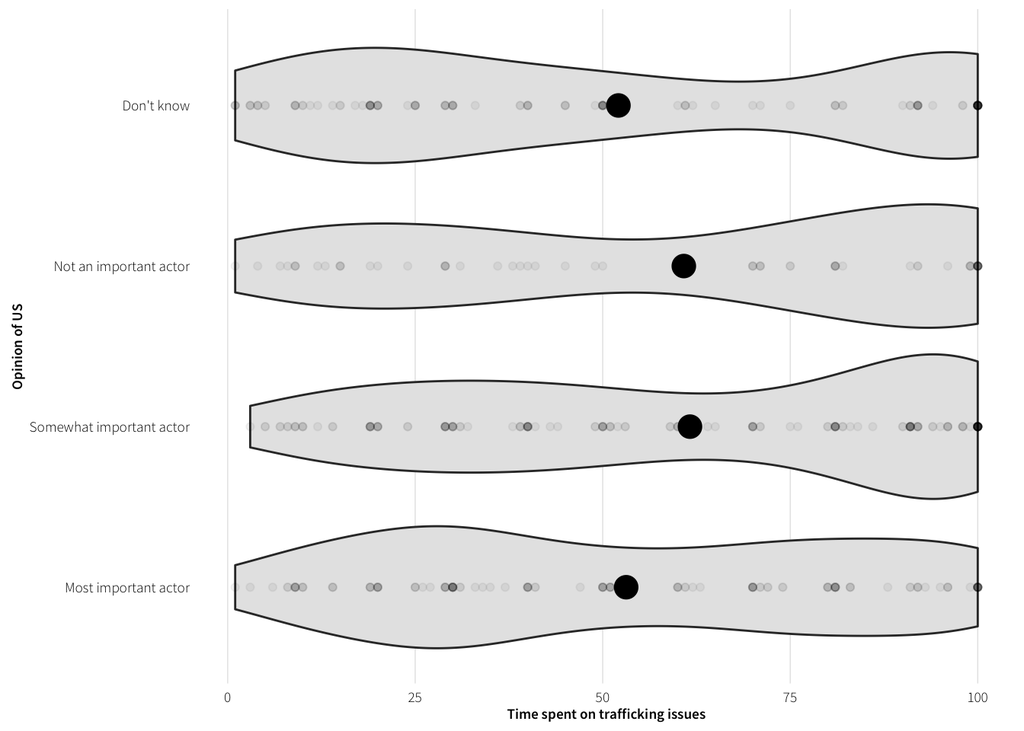

```r
ggplot(df.importance, aes(x=Q3.19, y=time.spent)) +
  geom_violin(fill="grey90") +
  geom_point(alpha=0.05) +
  geom_point(stat="summary", fun.y="mean", size=5) +
  labs(x="Opinion of US", y="Time spent on trafficking issues") +
  coord_flip() + theme_clean()
```

```r
kruskal.test(time.spent ~ importance_factor, data=df.importance)
```

```
##
##  Kruskal-Wallis rank sum test
##
## data:  time.spent by importance_factor
## Kruskal-Wallis chi-squared = 7.5031, df = 3, p-value = 0.05748
```

Ratio between min and max variance is low, so we’re okay:

```r
df.importance %>% group_by(importance_factor) %>%
  summarise(variance = var(time.spent, na.rm=TRUE)) %>%
  do(data_frame(ratio = max(.$variance) / min(.$variance)))
```

```
## Source: local data frame [1 x 1]
##
##      ratio
##      (dbl)
## 1 1.365997
```

ANOVA shows some small overall signifcant differences, but when decomposed, that effect is coming only from the tiny “Don’t know-Somewhat important actor” difference.

```r
time.anova <- aov(time.spent ~ importance_factor, data=df.importance)
summary(time.anova)
```

```
##                    Df Sum Sq Mean Sq F value Pr(>F)
## importance_factor   3   9603    3201     2.9 0.0346 *
## Residuals         491 541945    1104
## ---
## Signif. codes:  0 '***' 0.001 '**' 0.01 '*' 0.05 '.' 0.1 ' ' 1
## 27 observations deleted due to missingness
```

```r
(time.pairs <- TukeyHSD(time.anova))
```

```
##   Tukey multiple comparisons of means
##     95% family-wise confidence level
##
## Fit: aov(formula = time.spent ~ importance_factor, data = df.importance)
##
## $importance_factor
##                                                       diff        lwr       upr     p adj
## Somewhat important actor-Most important actor    8.5081361  -1.357648 18.373920 0.1184138
## Not an important actor-Most important actor      7.6875000  -5.294752 20.669752 0.4223730
## Don't know-Most important actor                 -1.0297619 -11.619626  9.560102 0.9944664
## Not an important actor-Somewhat important actor -0.8206361 -13.390747 11.749474 0.9983036
## Don't know-Somewhat important actor             -9.5378980 -19.618277  0.542481 0.0712221
## Don't know-Not an important actor               -8.7172619 -21.863334  4.428810 0.3198290
```

### Interaction with the US

Organizations that have been involved with the US are more likely to consider the US to play an important role in the countries they work in.

```r
involvement.table <- df.importance %>%
  xtabs(~ Q3.19 + us.involvement, .) %>% print
```

```
##                           us.involvement
## Q3.19                      FALSE TRUE
##   Most important actor        23  116
##   Somewhat important actor    48  134
##   Not an important actor      38   30
##   Don't know                  73   60
```

There’s an overall significant difference

```r
(involvement.chi <- chisq.test(involvement.table))
```

```
##
##  Pearson's Chi-squared test
##
## data:  involvement.table
## X-squared = 63.022, df = 3, p-value = 1.328e-13
```

```r
# Cramer's V for standardized measure of association
assocstats(involvement.table)
```

```
##                     X^2 df   P(> X^2)
## Likelihood Ratio 63.914  3 8.5598e-14
## Pearson          63.022  3 1.3278e-13
##
## Phi-Coefficient   : NA
## Contingency Coeff.: 0.328
## Cramer's V        : 0.347
```

```r
# Components of chi-squared
(components <- involvement.chi$residuals^2)
```

```
##                           us.involvement
## Q3.19                          FALSE      TRUE
##   Most important actor     13.379010  7.161705
##   Somewhat important actor  3.764597  2.015167
##   Not an important actor    8.614436  4.611257
##   Don't know               15.291006  8.185186
```

```r
1-pchisq(components, involvement.chi$parameter)
```

```
##                           us.involvement
## Q3.19                            FALSE        TRUE
##   Most important actor     0.003884710 0.066918431
##   Somewhat important actor 0.288031028 0.569264781
##   Not an important actor   0.034881684 0.202578528
##   Don't know               0.001584118 0.042335569
```

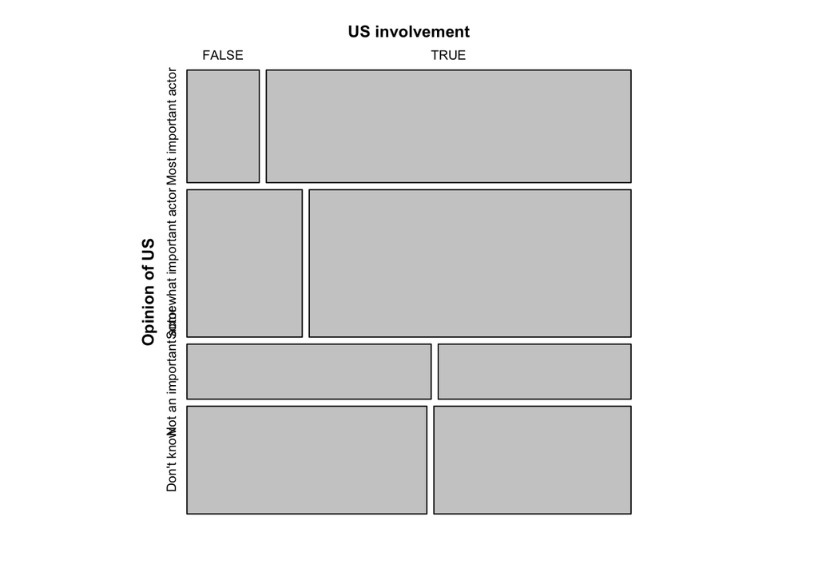

```r
# Visualize differences
mosaic(involvement.table,
       labeling_args=list(set_varnames=c(us.involvement="US involvement",
                                         Q3.19="Opinion of US"),
                          gp_labels=(gpar(fontsize=8))),
       gp_varnames=gpar(fontsize=10, fontface=2))
```

### Headquarters in the US

NGOs with headquarters in the US are not significantly different from their foreign counterparts in their opinions of the importance of the US.

```r
hq.table <- df.importance %>%
  xtabs(~ Q3.19 + us.hq, .) %>% print
```

```
##                           us.hq
## Q3.19                      FALSE TRUE
##   Most important actor       129   10
##   Somewhat important actor   171   11
##   Not an important actor      59    9
##   Don't know                 115   18
```

There’s no overall significant difference

```r
(hq.chi <- chisq.test(hq.table))
```

```
##
##  Pearson's Chi-squared test
##
## data:  hq.table
## X-squared = 7.1586, df = 3, p-value = 0.06701
```

```r
# Cramer's V is really low
assocstats(hq.table)
```

```
##                     X^2 df P(> X^2)
## Likelihood Ratio 6.9902  3 0.072211
## Pearson          7.1586  3 0.067010
##
## Phi-Coefficient   : NA
## Contingency Coeff.: 0.116
## Cramer's V        : 0.117
```

```r
# Components of chi-squared
(components <- hq.chi$residuals^2)
```

```
##                           us.hq
## Q3.19                           FALSE       TRUE
##   Most important actor     0.06130129 0.60535020
##   Somewhat important actor 0.19905971 1.96571460
##   Not an important actor   0.12221951 1.20691768
##   Don't know               0.27568266 2.72236626
```

```r
1-pchisq(components, hq.chi$parameter)
```

```
##                           us.hq
## Q3.19                          FALSE      TRUE
##   Most important actor     0.9960368 0.8952065
##   Somewhat important actor 0.9777410 0.5795532
##   Not an important actor   0.9890438 0.7513456
##   Don't know               0.9645351 0.4364398
```

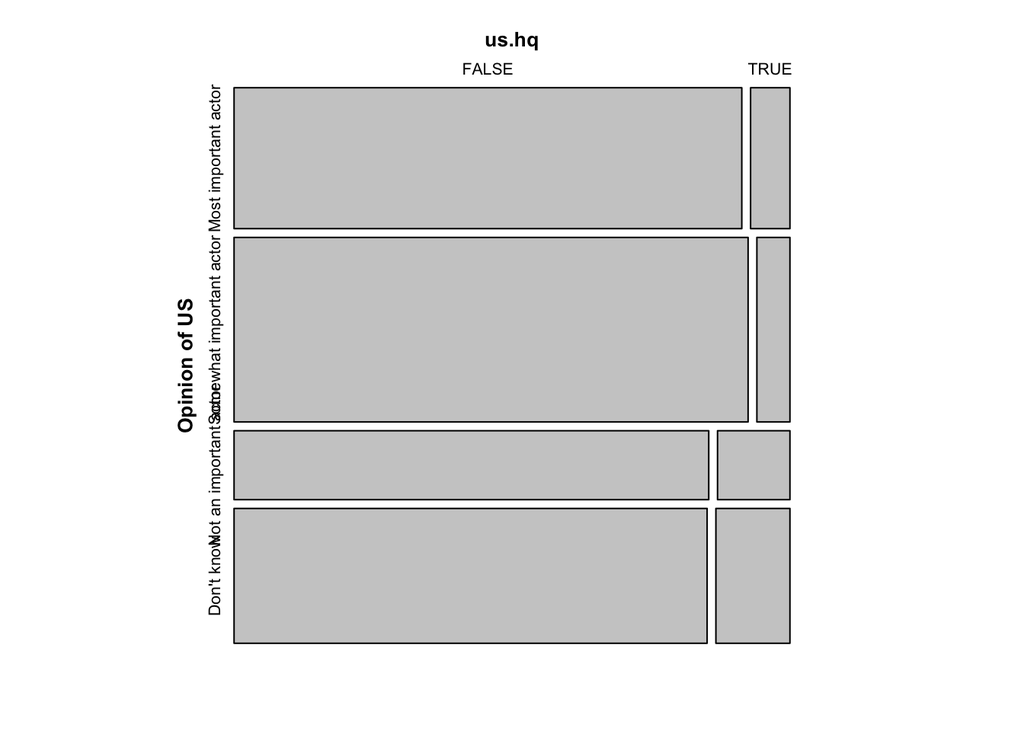

```r
# Visualize differences
mosaic(hq.table,
       labeling_args=list(set_varnames=c(us.involvement="US involvement",
                                         Q3.19="Opinion of US"),
                          gp_labels=(gpar(fontsize=8))),
       gp_varnames=gpar(fontsize=10, fontface=2))
```

## Are opinions of the US’s positivity associated with…?

**Important caveat**: Respondents were only asked about their opinions of the US’s work (Q3.25) if they indicated that the US was a somewhat important actor or the most important actor (Q3.19)

```r
df.positivity<- responses.full %>%
  select(Q3.25=Q3.25_collapsed, work.country, change_policy, avg_tier,
         improve_tip, change_policy, importance, received.funding, us.involvement,
         total.funding, total.freedom, us.hq, time.spent=Q2.1) %>%
  filter(!is.na(Q3.25)) %>%
  mutate(positivity_factor = factor(Q3.25, ordered=FALSE),
         log.total.funding = log1p(total.funding),
         time.spent = as.numeric(time.spent))
```

### Average tier rating

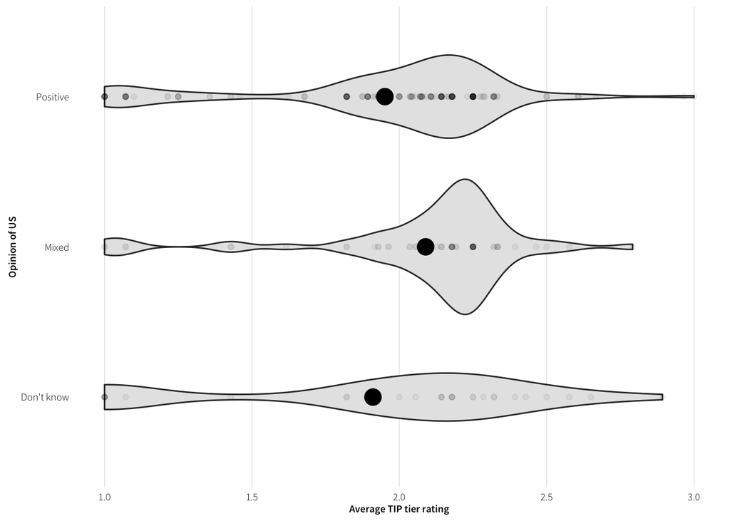

```r
ggplot(df.positivity, aes(x=Q3.25, y=avg_tier)) +
  geom_violin(fill="grey90") +
  geom_point(alpha=0.05, show.legend=FALSE) +
  geom_point(stat="summary", fun.y="mean", size=5) +
  labs(x="Opinion of US", y="Average TIP tier rating") +
  coord_flip() + theme_clean()
```

Check variance; it’s significant, so there’s heterogeneity

```r
kruskal.test(avg_tier ~ positivity_factor, data=df.positivity)
```

```
##
##  Kruskal-Wallis rank sum test
##
## data:  avg_tier by positivity_factor
## Kruskal-Wallis chi-squared = 9.3081, df = 2, p-value = 0.009523
```

But the ratio is okay

```r
df.positivity %>% group_by(positivity_factor) %>%
  summarise(variance = var(avg_tier, na.rm=TRUE)) %>%
  do(data_frame(ratio = max(.$variance) / min(.$variance)))
```

```
## Source: local data frame [1 x 1]
##
##      ratio
##      (dbl)
## 1 2.479382
```

ANOVA is significant, but right on the threshold, mostly driven by difference between positive and mixed.

```r
tier.anova.pos <- aov(avg_tier ~ positivity_factor, data=df.positivity)
summary(tier.anova.pos)
```

```
##                    Df Sum Sq Mean Sq F value Pr(>F)
## positivity_factor   2   1.11  0.5535   3.053 0.0486 *
## Residuals         310  56.20  0.1813
## ---
## Signif. codes:  0 '***' 0.001 '**' 0.01 '*' 0.05 '.' 0.1 ' ' 1
## 1 observation deleted due to missingness
```

```r
(tier.pairs.pos <- TukeyHSD(tier.anova.pos))
```

```
##   Tukey multiple comparisons of means
##     95% family-wise confidence level
##
## Fit: aov(formula = avg_tier ~ positivity_factor, data = df.positivity)
##
## $positivity_factor
##                            diff         lwr         upr     p adj
## Mixed-Don't know     0.17866608 -0.03023035 0.387562502 0.1104703
## Positive-Don't know  0.04045791 -0.14023074 0.221146556 0.8580130
## Positive-Mixed      -0.13820817 -0.28114111 0.004724777 0.0605376
```

### Improvement in TIP scores

NGOs who have positive opinions of the US are more likely to work in countries where the TIP rating has (slightly) decreased on average between 2000 and 2015. This may be because assigning a worse TIP rating to a country represents increased US diplomatic and economic pressure—it is a possible sign that NGOs like scorecard diplomacy.

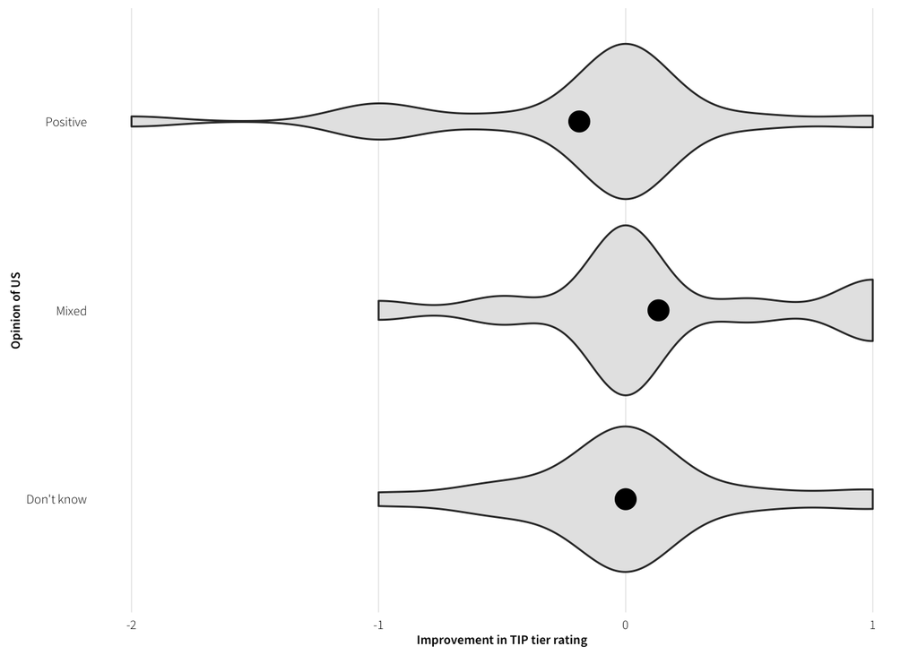

```r
ggplot(df.positivity, aes(x=Q3.25, y=improve_tip)) +
  geom_violin(fill="grey90") +
  geom_point(stat="summary", fun.y="mean", size=5) +
  labs(x="Opinion of US", y="Improvement in TIP tier rating") +
  coord_flip() + theme_clean()
```

Variance is not equal, but the ratio is small

```r
kruskal.test(improve_tip ~ positivity_factor, data=df.positivity)
```

```
##
##  Kruskal-Wallis rank sum test
##
## data:  improve_tip by positivity_factor
## Kruskal-Wallis chi-squared = 12.159, df = 2, p-value = 0.002289
```

```r
df.positivity %>% group_by(positivity_factor) %>%
  summarise(variance = var(improve_tip, na.rm=TRUE)) %>%
  do(data_frame(ratio = max(.$variance) / min(.$variance)))
```

```
## Source: local data frame [1 x 1]
##
##      ratio
##      (dbl)
## 1 1.803968
```

ANOVA shows overall significant difference. The difference between positive and mixed is very significant

```r
improve.anova.pos <- aov(improve_tip ~ positivity_factor, data=df.positivity)
summary(improve.anova.pos)
```

```
##                    Df Sum Sq Mean Sq F value   Pr(>F)
## positivity_factor   2   5.47  2.7353   8.304 0.000307 ***
## Residuals         310 102.11  0.3294
## ---
## Signif. codes:  0 '***' 0.001 '**' 0.01 '*' 0.05 '.' 0.1 ' ' 1
## 1 observation deleted due to missingness
```

```r
(improve.pairs.pos <- TukeyHSD(improve.anova.pos))
```

```
##   Tukey multiple comparisons of means
##     95% family-wise confidence level
##
## Fit: aov(formula = improve_tip ~ positivity_factor, data = df.positivity)
##
## $positivity_factor
##                           diff        lwr         upr     p adj
## Mixed-Don't know     0.1328125 -0.1487706  0.41439559 0.5081302
## Positive-Don't know -0.1877934 -0.4313537  0.05576683 0.1660765
## Positive-Mixed      -0.3206059 -0.5132732 -0.12793868 0.0003218
```

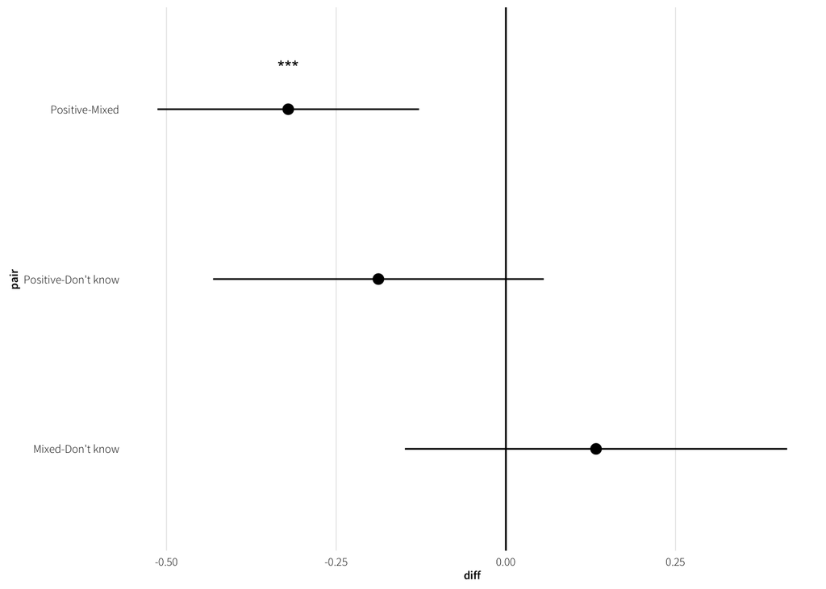

```r
improve.pairs.plot <- data.frame(improve.pairs.pos$positivity_factor) %>%
  mutate(pair = row.names(.),
         pair = factor(pair, levels=pair, ordered=TRUE),
         stars = add.stars(p.adj))

fig.improve.pairs.pos <- ggplot(improve.pairs.plot,
                               aes(x=pair, y=diff, ymax=upr, ymin=lwr)) +
  geom_hline(yintercept=0) +
  geom_text(aes(label=stars), nudge_x=0.25) +
  geom_pointrange() +
  theme_clean() + coord_flip()
fig.improve.pairs.pos
```

### Change in Cho scores

In contrast to the changes in actual TIP scores, NGOs that work in countries that show greater improvement in overall TIP policies are more likely to have a positive opinion of the US, perhaps because they are happy about the actual on-the-ground improvements.

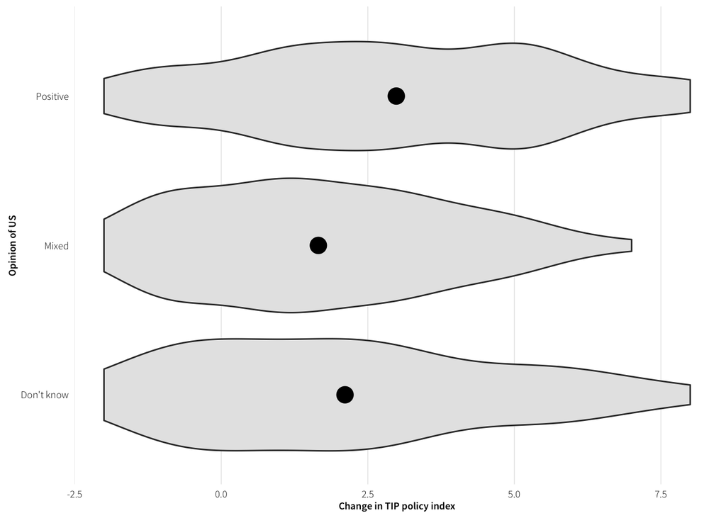

```r
ggplot(df.positivity, aes(x=Q3.25, y=change_policy)) +
  geom_violin(fill="grey90") +
  geom_point(stat="summary", fun.y="mean", size=5) +
  labs(x="Opinion of US", y="Change in TIP policy index") +
  coord_flip() + theme_clean()
```

Variance is not equal; ratio is okay

```r
kruskal.test(change_policy ~ positivity_factor, data=df.positivity)
```

```
##
##  Kruskal-Wallis rank sum test
##
## data:  change_policy by positivity_factor
## Kruskal-Wallis chi-squared = 14.1, df = 2, p-value = 0.0008676
```

```r
df.positivity %>% group_by(positivity_factor) %>%
  summarise(variance = var(change_policy, na.rm=TRUE)) %>%
  do(data_frame(ratio = max(.$variance) / min(.$variance)))
```

```
## Source: local data frame [1 x 1]
##
##      ratio
##      (dbl)
## 1 1.514886
```

ANOVA shows significant differences, mostly because of the difference between positive and mixed.

```r
cho.change.anova.pos <- aov(change_policy ~ positivity_factor,
                            data=df.positivity)
summary(cho.change.anova.pos)
```

```
##                    Df Sum Sq Mean Sq F value   Pr(>F)
## positivity_factor   2   97.3   48.64   7.409 0.000719 ***
## Residuals         310 2035.0    6.56
## ---
## Signif. codes:  0 '***' 0.001 '**' 0.01 '*' 0.05 '.' 0.1 ' ' 1
## 1 observation deleted due to missingness
```

```r
(cho.change.pairs.pos <- TukeyHSD(cho.change.anova.pos))
```

```
##   Tukey multiple comparisons of means
##     95% family-wise confidence level
##
## Fit: aov(formula = change_policy ~ positivity_factor, data = df.positivity)
##
## $positivity_factor
##                           diff        lwr       upr     p adj
## Mixed-Don't know    -0.4548611 -1.7119059 0.8021837 0.6708287
## Positive-Don't know  0.8748044 -0.2124987 1.9621074 0.1418826
## Positive-Mixed       1.3296655  0.4695593 2.1897717 0.0009270
```

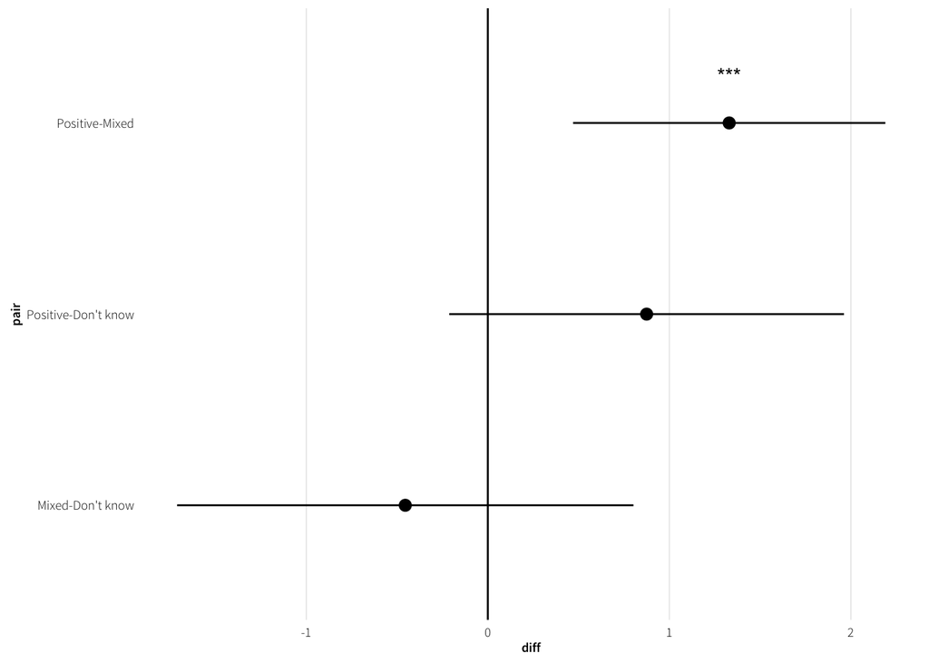

```r
cho.change.pairs.plot <- data.frame(cho.change.pairs.pos$positivity_factor) %>%
  mutate(pair = row.names(.),
         pair = factor(pair, levels=pair, ordered=TRUE),
         stars = add.stars(p.adj))

fig.cho.change.pairs.pos <- ggplot(cho.change.pairs.plot,
                                   aes(x=pair, y=diff, ymax=upr, ymin=lwr)) +
  geom_hline(yintercept=0) +
  geom_text(aes(label=stars), nudge_x=0.25) +
  geom_pointrange() +
  theme_clean() + coord_flip()
fig.cho.change.pairs.pos
```

### US funding received by the responding organization

```r
funding.table.pos <- df.positivity %>%
  xtabs(~ Q3.25 + received.funding, .) %>% print
```

```
##             received.funding
## Q3.25        FALSE TRUE
##   Don't know    26   10
##   Mixed         52   12
##   Positive     147   67
```

```r
(funding.chi.pos <- chisq.test(funding.table.pos))
```

```
##
##  Pearson's Chi-squared test
##
## data:  funding.table.pos
## X-squared = 3.8321, df = 2, p-value = 0.1472
```

```r
# Cramer's V for standardized measure of association
assocstats(funding.table.pos)
```

```
##                     X^2 df P(> X^2)
## Likelihood Ratio 4.0640  2  0.13107
## Pearson          3.8321  2  0.14719
##
## Phi-Coefficient   : NA
## Contingency Coeff.: 0.11
## Cramer's V        : 0.11
```

```r
# Components of chi-squared
(components <- funding.chi.pos$residuals^2)
```

```
##             received.funding
## Q3.25              FALSE        TRUE
##   Don't know 0.001610443 0.004071344
##   Mixed      0.822094834 2.078329636
##   Positive   0.262453717 0.663506589
```

```r
round(1-pchisq(components, funding.chi.pos$parameter), 3)
```

```
##             received.funding
## Q3.25        FALSE  TRUE
##   Don't know 0.999 0.998
##   Mixed      0.663 0.354
##   Positive   0.877 0.718
```

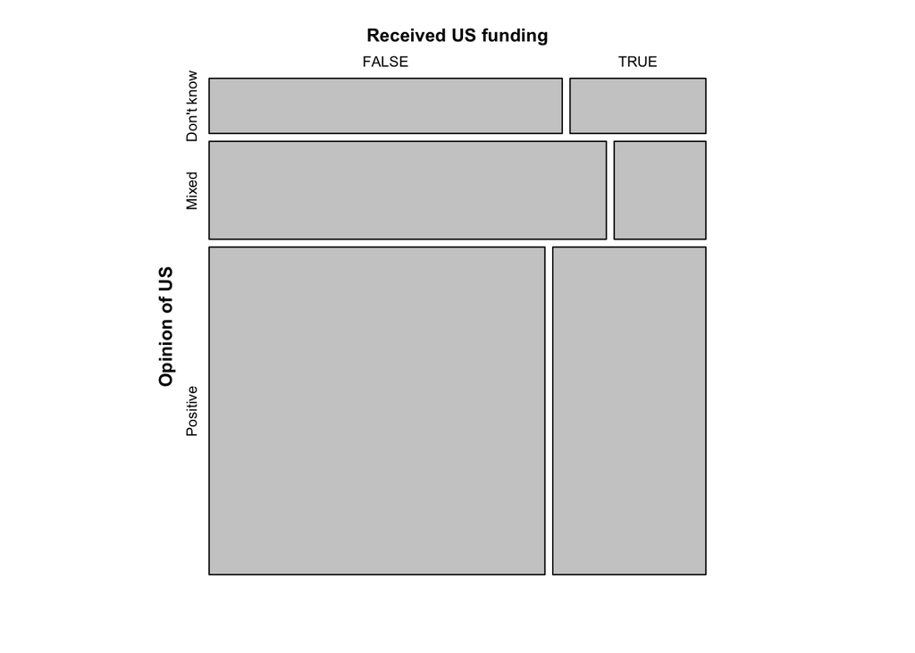

```r
# Visualize differences
mosaic(funding.table.pos,
       labeling_args=list(set_varnames=c(received.funding="Received US funding",
                                         Q3.25="Opinion of US"),
                          gp_labels=(gpar(fontsize=8))),
       gp_varnames=gpar(fontsize=10, fontface=2))
```

### US funding received by the country the organization works in

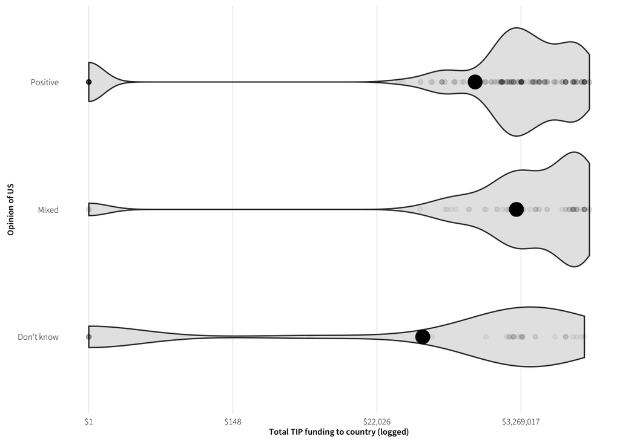

```r
ggplot(df.positivity, aes(x=Q3.25, y=log.total.funding)) +
  geom_violin(fill="grey90") +
  geom_point(alpha=0.05) +
  geom_point(stat="summary", fun.y="mean", size=5) +
  labs(x="Opinion of US", y="Total TIP funding to country (logged)") +
  scale_y_continuous(labels=trans_format("exp", dollar_format())) +
  coord_flip() + theme_clean()
```

Variance is not equal in all groups; ratio is 3.2ish, so it’s okayish

```r
kruskal.test(log.total.funding ~ positivity_factor, data=df.positivity)
```

```
##
##  Kruskal-Wallis rank sum test
##
## data:  log.total.funding by positivity_factor
## Kruskal-Wallis chi-squared = 9.3808, df = 2, p-value = 0.009183
```

```r
df.positivity %>% group_by(positivity_factor) %>%
  summarise(variance = var(log.total.funding, na.rm=TRUE)) %>%
  do(data_frame(ratio = max(.$variance) / min(.$variance)))
```

```
## Source: local data frame [1 x 1]
##
##      ratio
##      (dbl)
## 1 3.246233
```

ANOVA shows significant differences, mostly between mixed and don’t know (not between positive and mixed)

```r
funding.anova.pos <- aov(log.total.funding ~ positivity_factor, data=df.positivity)
summary(funding.anova.pos)
```

```
##                    Df Sum Sq Mean Sq F value  Pr(>F)
## positivity_factor   2    243  121.50   4.826 0.00865 **
## Residuals         302   7603   25.18
## ---
## Signif. codes:  0 '***' 0.001 '**' 0.01 '*' 0.05 '.' 0.1 ' ' 1
## 9 observations deleted due to missingness
```

```r
(funding.pairs.pos <- TukeyHSD(funding.anova.pos))
```

```
##   Tukey multiple comparisons of means
##     95% family-wise confidence level
##
## Fit: aov(formula = log.total.funding ~ positivity_factor, data = df.positivity)
##
## $positivity_factor
##                          diff        lwr       upr     p adj
## Mixed-Don't know     3.252743  0.7612851 5.7442008 0.0064809
## Positive-Don't know  1.818460 -0.3414378 3.9783587 0.1181484
## Positive-Mixed      -1.434282 -3.1347613 0.2661964 0.1172422
```

### Democracy (Freedom House political rights + civil liberties)

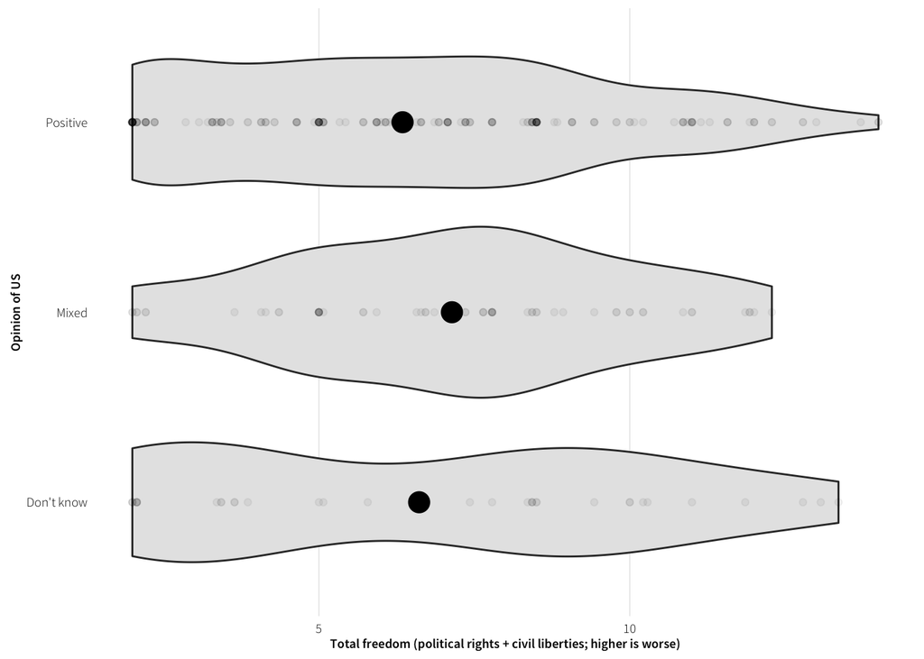

```r
ggplot(df.positivity, aes(x=Q3.25, y=total.freedom)) +
  geom_violin(fill="grey90") +
  geom_point(alpha=0.05) +
  geom_point(stat="summary", fun.y="mean", size=5) +
  labs(x="Opinion of US",
       y="Total freedom (political rights + civil liberties; higher is worse)") +
  coord_flip() + theme_clean()
```

Variance is equal in all groups

```r
kruskal.test(total.freedom ~ positivity_factor, data=df.positivity)
```

```
##
##  Kruskal-Wallis rank sum test
##
## data:  total.freedom by positivity_factor
## Kruskal-Wallis chi-squared = 3.477, df = 2, p-value = 0.1758
```

No significant differences

```r
democracy.anova.pos <- aov(total.freedom ~ positivity_factor, data=df.positivity)
summary(democracy.anova.pos)
```

```
##                    Df Sum Sq Mean Sq F value Pr(>F)
## positivity_factor   2   30.8   15.39   1.524  0.219
## Residuals         306 3090.0   10.10
## 5 observations deleted due to missingness
```

```r
(democracy.pairs.pos <- TukeyHSD(democracy.anova.pos))
```

```
##   Tukey multiple comparisons of means
##     95% family-wise confidence level
##
## Fit: aov(formula = total.freedom ~ positivity_factor, data = df.positivity)
##
## $positivity_factor
##                           diff       lwr       upr     p adj
## Mixed-Don't know     0.5272109 -1.050583 2.1050049 0.7113264
## Positive-Don't know -0.2664990 -1.632446 1.0994480 0.8901982
## Positive-Mixed      -0.7937099 -1.868207 0.2807874 0.1921411
```

### TODO: Type of TIP work

### Time spent on trafficking

The time NGOs spend on trafficking issues does not appear to be associated with their opinion of US importance.

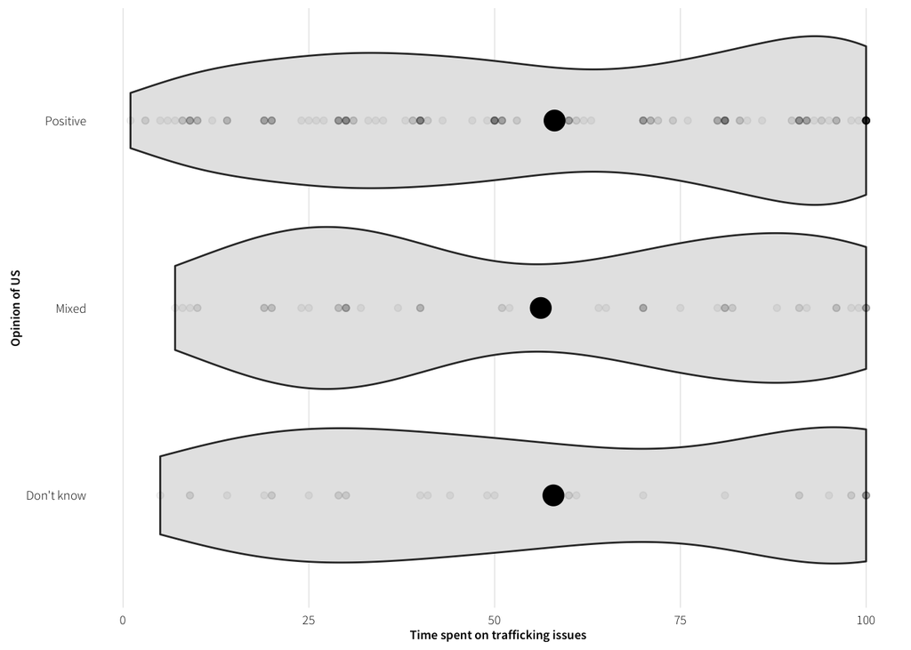

```r
ggplot(df.positivity, aes(x=Q3.25, y=time.spent)) +
  geom_violin(fill="grey90") +
  geom_point(alpha=0.05) +
  geom_point(stat="summary", fun.y="mean", size=5) +
  labs(x="Opinion of US", y="Time spent on trafficking issues") +
  coord_flip() + theme_clean()
```

Variance is equal in all groups:

```r
kruskal.test(time.spent ~ positivity_factor, data=df.positivity)
```

```
##
##  Kruskal-Wallis rank sum test
##
## data:  time.spent by positivity_factor
## Kruskal-Wallis chi-squared = 0.25432, df = 2, p-value = 0.8806
```

No significant differences between anything

```r
time.anova.pos <- aov(time.spent ~ positivity_factor, data=df.positivity)
summary(time.anova.pos)
```

```
##                    Df Sum Sq Mean Sq F value Pr(>F)
## positivity_factor   2    164    81.9   0.081  0.923
## Residuals         296 300856  1016.4
## 15 observations deleted due to missingness
```

```r
(time.pairs.pos <- TukeyHSD(time.anova.pos))
```

```
##   Tukey multiple comparisons of means
##     95% family-wise confidence level
##
## Fit: aov(formula = time.spent ~ positivity_factor, data = df.positivity)
##
## $positivity_factor
##                           diff        lwr      upr     p adj
## Mixed-Don't know    -1.7011710 -17.625650 14.22331 0.9656996
## Positive-Don't know  0.1546798 -13.590012 13.89937 0.9996126
## Positive-Mixed       1.8558508  -9.109375 12.82108 0.9161508
```

### Interaction with the US

```r
involvement.table.pos <- df.positivity %>%
  xtabs(~ Q3.25 + us.involvement, .) %>% print
```

```
##             us.involvement
## Q3.25        FALSE TRUE
##   Don't know     8   28
##   Mixed         16   48
##   Positive      45  169
```

There’s no significant difference

```r
(involvement.chi.pos <- chisq.test(involvement.table.pos))
```

```
##
##  Pearson's Chi-squared test
##
## data:  involvement.table.pos
## X-squared = 0.45477, df = 2, p-value = 0.7966
```

```r
# Tiny Cramer's V
assocstats(involvement.table.pos)
```

```
##                      X^2 df P(> X^2)
## Likelihood Ratio 0.44548  2  0.80032
## Pearson          0.45477  2  0.79661
##
## Phi-Coefficient   : NA
## Contingency Coeff.: 0.038
## Cramer's V        : 0.038
```

```r
# Components of chi-squared
(components <- involvement.chi.pos$residuals^2)
```

```
##             us.involvement
## Q3.25               FALSE         TRUE
##   Don't know 0.0010051591 0.0002830856
##   Mixed      0.2665928182 0.0750812427
##   Positive   0.0872412178 0.0245699756
```

```r
1-pchisq(components, involvement.chi.pos$parameter)
```

```
##             us.involvement
## Q3.25            FALSE      TRUE
##   Don't know 0.9994975 0.9998585
##   Mixed      0.8752056 0.9631553
##   Positive   0.9573171 0.9877902
```

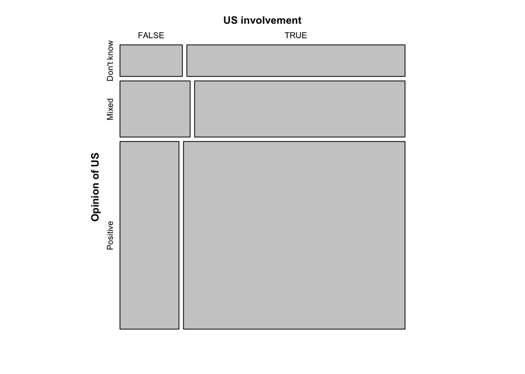

```r
# Visualize differences
mosaic(involvement.table.pos,
       labeling_args=list(set_varnames=c(us.involvement="US involvement",
                                         Q3.25="Opinion of US"),
                          gp_labels=(gpar(fontsize=8))),
       gp_varnames=gpar(fontsize=10, fontface=2))
```

### Headquarters in the US

NGOs with headquarters in the US are not significantly different from their foreign counterparts in their opinions of the US in general.

```r
hq.table.pos <- df.positivity %>%
  xtabs(~ Q3.25 + us.hq, .) %>% print
```

```
##             us.hq
## Q3.25        FALSE TRUE
##   Don't know    33    3
##   Mixed         59    5
##   Positive     201   13
```

There’s no overall significant difference, but some of the cells are too small

```r
(hq.chi.pos <- chisq.test(hq.table.pos))
```

```
##
##  Pearson's Chi-squared test
##
## data:  hq.table.pos
## X-squared = 0.4148, df = 2, p-value = 0.8127
```

```r
# Cramer's V is really, really low
assocstats(hq.table.pos)
```

```
##                     X^2 df P(> X^2)
## Likelihood Ratio 0.4018  2  0.81800
## Pearson          0.4148  2  0.81269
##
## Phi-Coefficient   : NA
## Contingency Coeff.: 0.036
## Cramer's V        : 0.036
```

```r
# Components of chi-squared
(components <- hq.chi.pos$residuals^2)
```

```
##             us.hq
## Q3.25              FALSE        TRUE
##   Don't know 0.010445425 0.145738550
##   Mixed      0.008674404 0.121028587
##   Positive   0.008621511 0.120290607
```

```r
1-pchisq(components, hq.chi.pos$parameter)
```

```
##             us.hq
## Q3.25            FALSE      TRUE
##   Don't know 0.9947909 0.9297224
##   Mixed      0.9956722 0.9412803
##   Positive   0.9956985 0.9416277
```

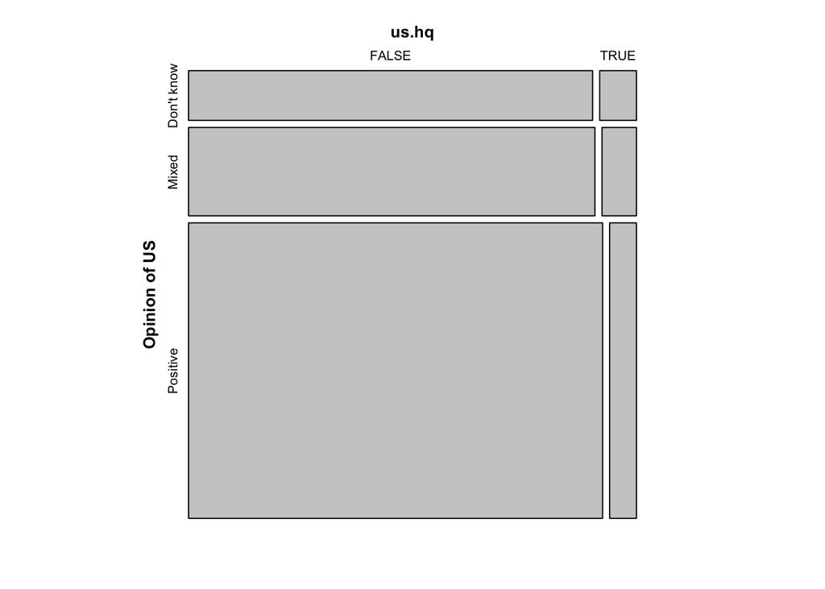

```r
# Visualize differences
mosaic(hq.table.pos,
       labeling_args=list(set_varnames=c(us.involvement="US involvement",
                                         Q3.25="Opinion of US"),
                          gp_labels=(gpar(fontsize=8))),
       gp_varnames=gpar(fontsize=10, fontface=2))
```

# TODOs and other questions

Does opinion of the US vary by: * Whether an NGO focuses on certain types of work?

In which countries does the US seem to have had more collaboration with NGOs?

CHECK: Opinions are not driven by cooptation - look at chapter 1 for boomerang type stuff - cooptation by donors - so in this case, the NGOs aren’t just being bought out?

Drop “don’t know”s - that leads to a t test for positivity

Create a nice simple summary table (like the one from Mike Ward’s paper) with graphs

```r
# # Type of work
# # TODO: work.country is not the most reliable identifier---there be NAs
# # Q2.2_X
# asdf <- responses.full %>%
#   select(survey.id, matches("Q2.2_\\d$")) %>%
#   gather(type_of_work, value, -survey.id) %>%
#   mutate(type_of_work = factor(type_of_work, levels=paste0("Q2.2_", seq(1:4)),
#                                labels=c("Organs", "Sex", "Labor", "Other"),
#                                ordered=TRUE))
# asdf %>%
#   group_by(type_of_work) %>%
#   summarise(bloop = n(),
#             derp = sum(value, na.rm=TRUE),
#             asdf = derp / n())
# # Should be 30, 408, 294, 116 with 479 total?

# #' Does NGO experience on the ground match improvements reported by the State Department?

# #' * Find country averages of government improvement, etc. - then show that X
# #'   number of countries show improvement, etc.
# #' * Report by organization and by country - how many countries has the US had
# #'   a positive influence + how many NGOs say the US has had a positive
# #'   influence
# full <- left_join(country.indexes, tip.change,
#                   by=c("work.country" = "countryname")) %>%
#   filter(num.responses >= 10) %>%
#   mutate(country_label = ifelse(num.responses >= 10, work.country, ""))

# ggplot(full, aes(x=improvement_score, y=change_policy, label=work.country)) +
#   geom_point() + geom_text(vjust=1.5) +
#   geom_hline(yintercept=0) +
#   scale_x_continuous(limits=c(0, 1)) +
#   scale_y_continuous(limits=c(-2, 6))

# ggplot(country.indexes, aes(x=work.country, y=improvement_score)) +
#   geom_bar(stat="identity") +
#   coord_flip()

# #' Compare improvement scores with actual changes in TIP score to get a sense
# #' of if NGO experiences reflect changes in rankings

# ggplot(country.indexes, aes(x=work.country, y=positivity_score)) +
#   geom_bar(stat="identity") +
#   coord_flip()


# # Importance opinions
# importance.opinions <- responses.all %>%
#   filter(Q3.19 == "Not an important actor") %>%
#   select(survey.id, clean.id, Q3.19, contains("TEXT"), Q4.1)

# responses.all$Q3.19 %>%
#   table %>% print %>% prop.table


# responses.countries %>%
#   xtabs(~ Q3.25 + Q3.26, .)

# ggplot(responses.orgs, aes(x = Q1.5.factor)) + geom_bar() +
#   labs(x = Hmisc::label(responses.orgs$Q1.5))


# # Importance of US
# asdf <- responses.all %>%
#   select(clean.id, Q1.2, Q3.8, Q3.6, Q3.7)

# inconsistent.no <- c(1020, 1152, 1226, 1267, 1323, 1405, 1515)
# inconsistent.dont.know <- c(1051, 1512)

# qwer <- asdf %>%
#   mutate(us.active = ifelse(clean.id %in% c(inconsistent.no, inconsistent.dont.know),
#                             "Yes", as.character(Q3.8)))

# qwer$us.active %>% table %>% print %>% prop.table

# sdfg <- qwer %>% group_by(clean.id) %>%
#   summarize(said.no = ifelse(any(us.active == "No", na.rm=TRUE), TRUE, FALSE))
# sdfg$said.no %>% table %>% print %>% prop.table




# # US importance and positivity



# # Importance of report
# responses.orgs$Q2.5 %>% table %>% print %>% prop.table
# responses.countries$Q3.23 %>% table %>% print %>% prop.table

# heard.of.tip <- responses.countries %>%
#   left_join(responses.orgs, by="survey.id") %>%
#   filter(Q2.5 == "Yes") %>%
#   group_by(survey.id) %>%
#   mutate(know.score = ifelse(Q3.22 == "Don't know", FALSE, TRUE)) %>%
#   select(know.score) %>% unique

# heard.of.tip$know.score %>% table %>% print %>% prop.table


# # Opinions of report
# opinions <- responses.all %>%
#   select(clean.id, Q1.2, home.country, work.country, Q3.21_1, Q3.21_4_TEXT, Q3.24.Text)

# not.used.tip.ids <- c(1094, 1099, 1106, 1114, 1157, 1221, 1244, 1269,
#                       1314, 1330, 1354, 1357, 1393, 1425)
# not.used.tip <- responses.all %>%
#   mutate(no.response = ifelse(is.na(Q3.21_1) & is.na(Q3.21_2) &
#                                 is.na(Q3.21_3) & is.na(Q3.21_4), TRUE, FALSE),
#          explicit.no = ifelse(clean.id %in% not.used.tip.ids, TRUE, FALSE)) %>%
#   select(clean.id, Q1.2, Q3.21_1, Q3.21_2, Q3.21_3, Q3.21_4, no.response, explicit.no) %>%
#   group_by(clean.id) %>%
#   summarize(no.response = ifelse(sum(no.response) > 0, TRUE, FALSE),
#             explicit.no = ifelse(sum(explicit.no) > 0, TRUE, FALSE))

# not.used.tip$explicit.no %>% table
```

▲ Back to top ▲